# Прогнозирование потребительских расходов муниципальных образований

Конкурс СберИндекса, направление «Прогнозирование»

## Краткое резюме

Мы прогнозируем потребительские расходы 2 028 муниципальных образований на горизонтах от месяца до года и ищем в них точки структурных изменений. **Главное число: на горизонте 3 мес. MAE эталона конкурса Prophet 1 581 ₽ → 1 217 ₽ у лучшей модели (−23,0%); R² по пулу 0,961 → 0,978.** Метод на одной странице — следующий раздел.

**Главный вывод: задача только выглядит как прогноз двух тысяч муниципалитетов — на деле это прогноз одного числа и разнос его по территориям.** Межрядовая составляющая ошибки не двигается ни одной из шести моделей, для которых посчитано разложение, а модель, не смотрящая на отдельные ряды, выигрывает там, где истории меньше всего (Результаты).

**Остальные результаты.**

1. **Выигрыш даёт информация со стороны, а не более сложная модель ряда.** Сезонность с длинных федеральных рядов и категории трат как обучающие ряды дают 23,0% к эталону против 7,3% у панельной модели без них. Выигрыш держится на 2 фолдах из 3: на первом, с самой короткой историей, эталон точнее (сравнение с эталоном).
2. **Наукаст и год вперёд.** На наукасте лучшая связка точнее эталона на 45,9% (839 против 1 550 ₽). На год вперёд, где панельным моделям не на чем учиться, лучшая — двухэтапная: точнее наивной и эталона на 39% и 40%, но это один фолд (пять горизонтов).
3. **Прогноз агрегата сверен с фактом 2025 года.** Первый этап двухэтапной модели — прогноз федерального ряда от декабря 2024 — ошибается в среднем на 3,8–4,5% (горизонты 1–12 мес.) против 7,0–17,1% у правил «как в декабре» и «как год назад». Муниципальный разрез 2025 года ещё не опубликован (прогноз на 2025 год).
4. **Ценность переноса падает до нуля с накоплением истории:** при обучении 12 мес. перенос снимает 7 590 ₽ ошибки, при 21 — добавляет 281 ₽ (ранговая корреляция с длиной обучения 0,96), а девять месяцев истории улучшают базовую модель в 10,4 раза — больше любого внешнего источника (закон переноса).
5. **Ловушка годовой сезонности.** Насильно включённая годовая сезонность даёт Prophet MAE 22 527 ₽ вместо 1 581 ₽ у настроек по умолчанию: на истории короче двух лет они её не включают (ловушка).
6. **Фундаментальные модели: на основном горизонте без дообучения все три семейства в среднем хуже наивной, дообучение доводит Chronos лишь до её уровня** — 1 830 ₽ против 1 852 ₽ у наивной (подробнее).
7. **Новости не дали значимого выигрыша ни в одной из трёх конструкций.** Самая мощная проверка — признаки в панельной модели на наукасте: на 396 рядах, покрытых новостями, ошибка ниже на 21,5 ₽, но интервал по фолдам [−77,9; +34,9] накрывает ноль (новости).
8. **Точки структурных изменений: решает преобразование ряда, а не алгоритм.** На сырых значениях методы со штрафом тревожат на 53,3–73,3% нетронутых рядов, на темпах роста — ни разу. Уровень обнаружения скромный, и раннего предупреждения на двух годах данных не показано (об обнаружении).

**Почему отрицательные результаты в резюме.** На 24 точках почти любой метод «улучшает» прогноз, если подбирать параметры по данным, на которых меряешь, — мы ловили на этом и себя (ансамбль). Поэтому каждый эффект здесь — вместе с тем, как он проверялся.

## Метод на одной странице

Справка о конструкции: из чего собрано решение и где что проверяется. Результаты — в следующем разделе, подробности — по ссылкам.

[figure not shown]

**Данные.** Панель СберИндекса: потребительские безналичные расходы МО по месяцам, январь 2023 — декабрь 2024, шесть категорий трат (одна из них — итог «Все категории»); в оценке — 2 028 рядов. Длинные федеральные и отраслевые ряды СберИндекса дают годы истории и обрезаются по origin каждого фолда. Подробно — Данные.

**Три героя сравнения.**

- **Лучшая панельная модель** (`global_gbm_stack_factor`). Один градиентный бустинг на всех МО сразу предсказывает не уровень, а во сколько раз изменится ряд к последнему месяцу, — так Магадан и сельский район учат модель одному и тому же. Сезонность, которой короткая панель не видела, модель берёт у общего фактора — прогноза длинного федерального ряда — и у категорий трат, поданных отдельными обучающими рядами. Подробно — Перенос с длинных рядов.
- **Двухэтапная модель** (`two_stage`) — по образцу top-down по историческим долям ([Hyndman & Athanasopoulos, FPP3, § 11.2](https://otexts.com/fpp3/single-level.html)): прогнозирует один федеральный ряд по его собственной длинной истории и разносит прогноз по МО долями — медианой отношения ряда к федеральному индексу за последние месяцы обучения. Показатель подушевой, и панель в агрегат не суммируется: «доля» здесь — отношение, а не часть суммы, поэтому согласование иерархии к ней неприменимо. На сами ряды при прогнозе динамики модель не смотрит. Подробно — Конструктивная проверка: прогноз одного числа и разнос.
- **Эталон конкурса** (`prophet`) — Prophet с настройками библиотеки по умолчанию, каждый ряд отдельно, без единого нашего аргумента. Подробно — в разделе о нём.

**Разладки.** Шесть детекторов (PELT, BinSeg, Window, BottomUp, ядровой (RBF) и CUSUM) в расширяющемся окне при неизвестном числе изломов, на темпах роста ряда; флаг — излом в последних трёх точках окна. Штраф выбирается на стенде с врезками известной величины в настоящие ряды — до прогона на реальных данных. Сигнал по панели — доля территорий, у которых в месяце начался эпизод тревоги. Подробно — в разделе об обнаружении.

**Протокол.** Скользящий origin с расширяющимся окном: основной разбор — три фолда на горизонте 3 месяца (обучение 15, 18 и 21 мес.), плюс наукаст и горизонты 1, 3, 6 и 12 мес. — на каждом столько фолдов, сколько допускают 24 точки. Все модели проверяются на одних и тех же парах ряд × фолд; протокол живёт в `configs/*.yaml`, а не в коде моделей. Подробно — Протокол оценки и Пять горизонтов.

**Метрики.** MAE в рублях — основная: простое среднее по парам ряд × фолд, у каждой территории вес один, и в рублях сильнее весят МО с высокими расходами. Поэтому рядом R² — пулом по всем тестовым точкам и медианой по парам (среднее по парам на трёх точках вырождено), и масштабно-независимые MASE и sMAPE. Подробно — Про метрики.

## Результаты

> **Задача только выглядит как прогноз двух тысяч муниципалитетов. На деле это прогноз одного числа и разнос его по территориям.**

Это главный вывод работы. Он получен двумя независимыми способами, и оба приведены ниже: сначала измерением, потом конструкцией.

**Измерение.** Ошибку прогноза можно разделить на две части: промах мимо общего движения страны и разброс между муниципалитетами. Вторая часть укладывается в **695–849 ₽ по всем 18 сочетаниям модели и фолда** при стандартном отклонении 47. Первая гуляет от 67 до 2 711, и вместе с ней MAE — от 781 до 3 535. Всё, что отличает хорошую модель от плохой на этих данных, — попадание в общее движение. Остальное не сдвинула ни одна из шести моделей, для которых посчитано разложение.

**Конструкция.** Двухэтапная модель прогнозирует **один** федеральный ряд по его собственной длинной истории и разносит результат долями. На отдельные ряды при прогнозе динамики она не смотрит вовсе — и на фолде с самой короткой историей оказывается **лучшей из всех**, обходя в том числе наивную модель, которую там не обошёл никто другой.

Лучшая по среднему модель даёт **MAE 1 217 ₽** против **1 581 ₽** у эталона конкурса — выигрыш **23,0%** на 2 028 муниципалитетах и 6 084 парах ряд × фолд. Впереди она на 2 фолдах из 3, а на первом эталон точнее; пять верхних конструкций по фолдам неразличимы (сравнение с эталоном). Но само это число — побочный продукт. Результат — то, почему оно именно такое.

### Закон: перенос замещает недостающую историю ровно в той мере, в какой её недостаёт

Двадцать четыре точки на ряд — корневое ограничение задачи. Мы перепробовали пять конструкций, чтобы обойти его чужими данными, и обнаружили не рецепт, а зависимость.

Протокол даёт три фолда, три точки — мало для закономерности. Поэтому то же самое посчитано на всех origin’ах, которые панель допускает: обучение от 12 до 21 месяца, десять длин (`scripts/training_length_sweep.py`).

| обучение, мес | наивная MAE | базовая MAE | доли категорий | общий фактор | стек категорий | стек + фактор | предобучение |
| --- | --- | --- | --- | --- | --- | --- | --- |
| 12 | 4 474,47 | 9 213,03 | −550,57 | −7 606,50 | 3 651,99 | −7 590,27 | 1 639,45 |
| 13 | 4 175,42 | 3 480,05 | 340,49 | −236,42 | −1 620,37 | −1 468,56 | 1 304,89 |
| 14 | 2 608,97 | 2 582,62 | 33,80 | −935,75 | −455,67 | −995,49 | −74,03 |
| 15 | 804,67 | 2 387,23 | −528,61 | −556,00 | −275,43 | −746,04 | −661,76 |
| 16 | 1 299,77 | 1 872,27 | −328,62 | 398,85 | −271,74 | −184,15 | −136,94 |
| 17 | 1 421,50 | 1 565,54 | −116,98 | −57,86 | −172,09 | −534,48 | −153,54 |
| 18 | 1 217,61 | 1 127,97 | −34,12 | −176,68 | −357,16 | −282,65 | 32,61 |
| 19 | 1 299,44 | 899,26 | −21,56 | 52,78 | −83,87 | −62,28 | 198,58 |
| 20 | 1 620,68 | 916,69 | −34,17 | 73,97 | 120,11 | 40,62 | 78,61 |
| 21 | 3 534,89 | 883,12 | −16,37 | 41,48 | 211,12 | 281,48 | 648,44 |

Столбцы источников — это **выигрыш к базовой панельной модели**: отрицательное число означает, что источник помогает.

|  | ранговая корреляция выигрыша с длиной обучения |
| --- | --- |
| доли категорий | 0,19 |
| общий фактор | 0,73 |
| стек категорий | 0,38 |
| стек + фактор | 0,96 |
| предобучение | −0,08 |

Закономерность держится почти без исключений. Чем длиннее история, тем меньше даёт перенос, и на правом краю он уже мешает. При двенадцати месяцах обучения лучшая конструкция снимает с базовой модели больше семи тысяч рублей ошибки; при двадцати одном — добавляет.

**И та же таблица содержит главное ограничение всей работы, выраженное числом.** Базовая панельная модель от 12 к 21 месяцу улучшается в **десять с лишним раз**. Наивная модель за тот же период не улучшается вовсе: её ошибка зависит от того, какие месяцы попали в тест, а не от длины истории.

> Девять дополнительных месяцев данных дают больше, чем любая конструкция переноса, любая фундаментальная модель и любой внешний источник вместе взятые. **Длину ряда заменить нельзя. Можно занять недостающую сезонность у того, у кого она есть, — и ровно настолько, насколько её недостаёт.**

Оговорка: десять origin’ов идут подряд и пересекаются, поэтому усреднять их как независимые наблюдения нельзя. Смысл таблицы — в форме зависимости, а не в уровне чисел.

### Механизм: ошибка состоит из двух частей, и двигается только одна

Почему закон устроен именно так, видно из разложения ошибки (`scripts/error_decomposition.py`).

Средняя ошибка не говорит, ошибается ли модель по-разному в разных муниципалитетах или одинаково во всех сразу. А это разные болезни. Разделить их можно так: домножить прогноз на один множитель, подобранный задним числом по факту, — то есть угадать общее движение страны идеально, ничего не узнав про отдельные территории. Насколько упадёт ошибка, настолько она и состояла из **общего смещения**; остаток — **разброс между рядами**.

| модель | фолд 0: разброс | фолд 0: смещение | фолд 1: разброс | фолд 1: смещение | фолд 2: разброс | фолд 2: смещение |
| --- | --- | --- | --- | --- | --- | --- |
| global_gbm | 820,24 | 1 566,99 | 761,52 | 366,46 | 813,01 | 70,11 |
| global_gbm_cat | 836,44 | 1 022,17 | 802,69 | 291,16 | 799,50 | 67,25 |
| global_gbm_factor | 849,36 | 981,87 | 763,14 | 188,15 | 819,88 | 104,72 |
| global_gbm_stack_factor | 714,52 | 926,66 | 751,05 | 94,27 | 809,91 | 354,69 |
| naive_last | 695,14 | 109,54 | 774,09 | 443,52 | 823,66 | 2 711,23 |
| two_stage | 695,14 | 86,11 | 774,09 | 812,55 | 823,66 | 986,88 |

Числа стоит прочитать дважды.

**Разброс между рядами не двигается вообще.** По всем 18 сочетаниям модели и фолда он укладывается в диапазон от 695 до 849 рублей при стандартном отклонении 47. При этом сама MAE на тех же сочетаниях гуляет от 781 до 3 535.

**Значит всё, что отличает хорошую модель от плохой на этих данных, — это попадание в общее движение страны.** Остальное — предел информации, который не сдвинула ни одна из моделей, для которых посчитано разложение. Задача только выглядит как «спрогнозировать две тысячи муниципалитетов»; на деле это «спрогнозировать одно общероссийское число и разнести его по территориям».

Вот как выглядит промах в общем движении на первом фолде. Обучение кончается мартом 2024, прогнозируем апрель-июнь:

| модель | MAE | смещение | разброс | изменение за 3 мес, прогноз | изменение за 3 мес, факт |
| --- | --- | --- | --- | --- | --- |
| naive_last | 804,67 | 109,54 | 695,14 | 0,00 | 1,06 |
| two_stage | 781,24 | 86,11 | 695,14 | 2,04 | 1,06 |
| global_gbm | 2 387,23 | 1 566,99 | 820,24 | −8,32 | 1,06 |
| global_gbm_cat | 1 858,61 | 1 022,17 | 836,44 | −5,65 | 1,06 |
| global_gbm_factor | 1 831,22 | 981,87 | 849,36 | −11,30 | 1,06 |
| global_gbm_stack_factor | 1 641,18 | 926,66 | 714,52 | −7,84 | 1,06 |

Базовая модель предсказывает падение расходов на 8,3% за три месяца. Факт — рост на 1,1%. Две трети её ошибки на этом фолде — этот единственный промах, одинаковый для всех 2 028 территорий.

Откуда он берётся. Признакам нужно шесть точек истории, поэтому трёхмесячные переходы в обучающей части первого фолда — это в основном сентябрь→декабрь (рост на четверть) и декабрь→март (падение на пятую часть). **Апреля, мая и июня модель не видела ни разу** и продолжает зимнюю динамику в лето.

Отсюда и закон. Внешний источник лечит смещение — он приносит знание о месяце, которого в обучении не было. Разброс он не трогает, потому что разброс трогать нечем. А по мере накопления истории модель узнаёт месяцы сама, смещение падает (с 66% ошибки на первом фолде до 8% на третьем), и лечить становится нечего.

### Конструктивная проверка: прогноз одного числа и разнос

Разложение ошибки — измерение. Оно показывает, что смещение решает всё, но не доказывает, что на одном общем движении можно **построить** прогноз: в панельной модели общий фактор заходит нормировкой цели, и бустинг волен им не пользоваться.

Двухэтапная модель проверяет тезис в лоб. Она прогнозирует **один** федеральный ряд по его собственной истории в 64–70 месяцев — ровно та длина, нехватка которой всё и определяет, — и разносит результат долями `y_i(t) / F(t)`, оценёнными по обучающей части. На динамику отдельных рядов она при этом не смотрит вовсе.

|  | фолд 0: обучение 15 мес | фолд 1: 18 мес | фолд 2: 21 мес | среднее | место в фолде 0 |
| --- | --- | --- | --- | --- | --- |
| наивная | 804,67 | 1 217,61 | 3 534,89 | 1 852,39 | 2 |
| двухэтапная, сырой агрегат | 781,24 | 1 586,64 | 1 810,54 | 1 392,81 | 1 |
| двухэтапная, сезонно сглаженный агрегат | 2 591,70 | 1 217,61 | 3 534,89 | 2 448,07 | 5 |
| панельная модель, без внешних источников | 2 387,23 | 1 127,97 | 883,12 | 1 466,10 | 4 |
| лучшая по среднему | 1 641,18 | 845,32 | 1 164,60 | 1 217,03 | 3 |

**На первом фолде двухэтапная модель — лучшая из всех 32 моделей, 781 ₽.** Она обходит и наивную модель, которую на этом фолде не обошёл больше никто, и лучшую по среднему связку, которая проигрывает ей 860 ₽ на ряд. Модель, не знающая про отдельные муниципалитеты ничего, кроме их доли, оказывается точнее всех там, где истории меньше всего.

На втором и третьем фолдах она проигрывает: 1 587 и 1 811 против 845 и 1 165. Тезис, стало быть, верен не вообще, а **в той же зависимости от длины истории**, что и всё остальное в этой работе. Чем больше месяцев, тем больше значит собственная динамика ряда, и тем меньше — общее движение.

Разложение ошибки показывает это с неожиданной точностью: **разброс двухэтапной модели совпадает с разбросом наивной до рубля** — 695, 774 и 824 по трём фолдам. Это не совпадение, а тождество по построению: обе модели дают прогноз вида «последнее значение ряда, умноженное на общий множитель», и после идеальной калибровки этого множителя они становятся одной и той же моделью. Разница между ними — ровно общий фактор, и он стоит 460 рублей из 1 852.

**Сезонно сглаженный агрегат для разноса не годится, и это видно до прогона.** Сглаживание вычищает именно ту сезонность, которую разнос делит между муниципалитетами: разделив панель на ряд без сезонности, мы оставляем всю её сезонность внутри доли, и доля перестаёт быть устойчивой. Прогон подтверждает: 2 448 против 1 393, причём внутренний бэктест на сглаженном ряде выбирает `random_walk` — то есть не находит в нём ничего прогнозируемого, и модель вырождается в наивную.

### Таблица по фолдам: среднее скрывает полную перемену мест

|  | фолд 0: обучение 15 мес | фолд 1: 18 мес | фолд 2: 21 мес | среднее | место в фолде 0 | место в фолде 1 | место в фолде 2 |
| --- | --- | --- | --- | --- | --- | --- | --- |
| наивная: оставить как в прошлом месяце | 804,67 | 1 217,61 | 3 534,89 | 1 852,39 | 2 | 7 | 9 |
| эталон конкурса (Prophet по умолчанию) | 1 095,68 | 1 441,83 | 2 204,84 | 1 580,78 | 3 | 8 | 7 |
| двухэтапная: одно число и разнос долями | 781,24 | 1 586,64 | 1 810,54 | 1 392,81 | 1 | 9 | 6 |
| панельная модель, без внешних источников | 2 387,23 | 1 127,97 | 883,12 | 1 466,10 | 9 | 5 | 2 |
| панельная + доли категорий | 1 858,61 | 1 093,85 | 866,75 | 1 273,07 | 6 | 4 | 1 |
| панельная + общий фактор | 1 831,22 | 951,30 | 924,60 | 1 235,71 | 5 | 3 | 3 |
| панельная + категории рядами | 2 111,79 | 770,82 | 1 094,23 | 1 325,61 | 8 | 1 | 4 |
| панельная + фактор + категории рядами | 1 641,18 | 845,32 | 1 164,60 | 1 217,03 | 4 | 2 | 5 |
| Chronos-Bolt, дообученный | 2 001,46 | 1 152,29 | 2 337,31 | 1 830,35 | 7 | 6 | 8 |

**На первом фолде наивную модель обходит только двухэтапная** — 781 против 805; наша лучшая по среднему даёт там 1 641. На третьем она же худшая в таблице — 3 535 против 867 у лучшей там: «панельная + доли категорий». Ни одна из 32 моделей не выигрывает у наивной на всех трёх фолдах: панельные берут второй и третий, наивная — первый.

Это не оговорка мелким шрифтом, а прямое следствие механизма. Первый фолд — календарно спокойный: факт за три месяца плюс один процент. Когда ничего не происходит, «оставить как есть» — оптимальный прогноз, а любая модель, обученная на зимних переходах, выдумывает движение. Третий фолд — декабрьский скачок на четверть, и там наивная модель промахивается на всю его величину.

Отсюда же следует, как читать среднее по трём фолдам: это не «качество модели», а качество модели на конкретных девяти месяцах 2024 года.

### Сравнение с базовой моделью конкурса

Оговорка, без которой сравнение будет нечестным: **базовая модель конкурса — это Prophet, разработка Meta, а не модель Сбера.** Что СберИндекс использует внутри, публично не описано. Мы сравниваемся с тем эталоном, который назван в условиях.

[output not shown]

**Почему Prophet упирается в потолок.** Он обрабатывает каждый ряд отдельно и с нуля, а пятнадцати точек мало, чтобы оценить что-то сверх тренда: на такой истории он по умолчанию не включает вообще ни одной сезонной компоненты — и правильно делает. Это не дефект модели, а предел того, что видно в одном ряду.

**Почему наша работает.** Она не оценивает годовой цикл по одному ряду. Она спрашивает только «во сколько раз изменится» — и этот вопрос одинаково устроен у Магадана с семьюдесятью четырьмя тысячами рублей и у сельского района с десятью. Недостающее в одном ряду добирается у двух тысяч похожих, а недостающий месяц — у федерального ряда и у категорий трат.

**Выигрыш — 23,0%.** Против Prophet с его собственными настройками по умолчанию, без единого нашего аргумента. Эталон при этом не слабый: он обходит наивный прогноз «оставить как в прошлом месяце» на 14,7%, так что планка настоящая. Но выигрыш держится на 2 фолдах из 3. На первом фолде, с самой короткой историей, эталон точнее: 1 096 ₽ против 1 641 ₽, ошибка лучшей модели там в 1,5 раза больше. Пять верхних конструкций по фолдам неразличимы: по среднему их разделяет 60 ₽, пофолдовые интервалы разниц с верхней строкой накрывают ноль у всех четырёх, а на третьем фолде каждая из них обходит верхнюю строку на 240–298 ₽. Поэтому рекомендуемая модель выбирается по длине истории, а не по верхней строке таблицы (что из этого следует для практики). По R² — пулом и медианой по парам ряд × фолд сразу — лучшая модель впереди на 2 фолдах из 3, как и по MAE. Таблица ниже показывает выигрыш по фолдам и с интервалами.

Из этих 23,0% сама панельная модель даёт 7,3%, остальное — перенос недостающей сезонности. Разбор по источникам — в разделе Перенос с длинных рядов.

**Чем платим.** Prophet интерпретируем — видно отдельно тренд, отдельно сезонность, и он сам даёт доверительные интервалы. Нашей модели интервалы построить можно — конформно, по остаткам на обучающих фолдах, а у Chronos и TimesFM их дают квантили, — но мы их не приводим: на горизонтах 6 и 12 месяцев фолдов один-два, и покрытие интервала на них не проверить, а на горизонтах 1 и 3 месяца, где проверить можно, интервалы не строились — это первое, что стоит добавить. И нашей модели нужна панель: на одном ряду без соседей подход неприменим вообще.

#### Модель против эталона: по фолдам и с интервалами

Выигрыш к эталону — плюс, если модель точнее, — для пяти верхних панельных конструкций, двухэтапной модели, дообученного Chronos и наивной, с двумя интервалами: по парам ряд × фолд и по фолдам.

| модель | MAE, ₽ | выигрыш к эталону, ₽ | парный 95% ДИ | по фолдам, 95% ДИ по t(2) | фолдов выиграно | пар выиграно |
| --- | --- | --- | --- | --- | --- | --- |
| общий фактор + категории рядами | 1 217 | +364 | [+338; +389] | [−1 669; +2 396] | 2 из 3 | 70% |
| общий фактор (федеральная эластичность) | 1 236 | +345 | [+315; +375] | [−2 178; +2 868] | 2 из 3 | 66% |
| общий фактор (эластичность по регионам) | 1 266 | +315 | [+283; +346] | [−2 440; +3 069] | 2 из 3 | 65% |
| доли категорий как признаки | 1 273 | +308 | [+278; +337] | [−2 303; +2 919] | 2 из 3 | 68% |
| общий фактор + доли категорий | 1 277 | +304 | [+276; +332] | [−2 213; +2 821] | 2 из 3 | 64% |
| двухэтапная (top-down по долям) | 1 393 | +188 | [+167; +208] | [−535; +911] | 2 из 3 | 57% |
| Chronos-Bolt small, дообученный | 1 830 | −250 | [−272; −227] | [−1 755; +1 256] | 1 из 3 | 42% |
| наивная | 1 852 | −272 | [−299; −245] | [−2 550; +2 007] | 2 из 3 | 47% |

| горизонт, мес. | фолдов | лучшая панельная | двухэтапная |
| --- | --- | --- | --- |
| 1 | 9 | 8 из 9 | 7 из 9 |
| 3 | 3 | 2 из 3 | 2 из 3 |
| 6 | 2 | 2 из 2 | 2 из 2 |
| 12 | 1 | нет прогноза | 1 из 1 |
| всего | 15 | 12 из 14 | 12 из 15 |

**Две оценки неопределённости, и обе верны.** Парные интервалы узкие, потому что пар много — 6 084 пары ряд × фолд. Но ошибки внутри одного фолда сильно связаны: все муниципалитеты переживают один и тот же месяц, и промах по общему движению промахивается сразу у всех. Если считать неопределённость по фолдам, а их три, интервалы накрывают ноль у всех восьми моделей таблицы. Парная оценка говорит: на этих 2 028 муниципалитетах в эти тестовые месяцы выигрыш лучшей модели держится на большинстве территорий — она точнее эталона на 70% пар ряд × фолд. Фолдовая говорит: трёх тестовых окон слишком мало, чтобы утверждать, что выигрыш повторится на любом другом периоде. Мы приводим обе и не выбираем удобную.

**Счёт по горизонтам сильнее одной строки.** На горизонтах 1, 3 и 6 мес., у каждого свои origin’ы, лучшая панельная модель точнее эталона в 12 фолдовых сравнениях из 14, двухэтапная — в 12 из 15 на горизонтах 1, 3, 6 и 12 мес. Это счёт, а не тест: фолды разных горизонтов пересекаются по тестовым месяцам и независимыми не являются. Но знак выигрыша повторяется почти везде, а не только в среднем по трём фолдам основного разбора.

Пофолдовый разбор в разделе Результаты показывает, что осторожность здесь не ритуальная: ни одна модель не выигрывает у наивной на всех трёх фолдах.

### Что из этого следует для практики

Вывод неудобный, и мы приводим его первым, а не прячем в ограничения.

Конкурсная оценка усредняет три фолда, и по среднему выигрывает связка «общий фактор плюс категории рядами». Но прогнозировать в реальности предстоит **вперёд от конца данных**, то есть с двадцатью четырьмя месяцами обучения — а это дальше правого края нашей развёртки, где перенос уже не помогает.

| обучение, мес | лучшая конструкция | её MAE | базовая MAE |
| --- | --- | --- | --- |
| 12 | общий фактор | 1 606,52 | 9 213,03 |
| 13 | стек категорий | 1 859,68 | 3 480,05 |
| 14 | стек + фактор | 1 587,13 | 2 582,62 |
| 15 | наивная | 804,67 | 2 387,23 |
| 16 | наивная | 1 299,77 | 1 872,27 |
| 17 | стек + фактор | 1 031,07 | 1 565,54 |
| 18 | стек категорий | 770,82 | 1 127,97 |
| 19 | стек категорий | 815,39 | 899,26 |
| 20 | доли категорий | 882,52 | 916,69 |
| 21 | доли категорий | 866,75 | 883,12 |

В таблице намеренно оставлена и наивная модель, и она выигрывает дважды — при пятнадцати и шестнадцати месяцах обучения, обходя все панельные конструкции сразу. **Оба самых длинных обучения выигрывают доли категорий**, и это ближайшее к реальной задаче, что у нас есть.

Важнее того, кто выиграл, величина разрыва. При двенадцати месяцах перенос отделяет непригодную модель от рабочей: 9 213 против 1 607. При двадцати одном речь идёт о шестнадцати рублях из восьмисот восьмидесяти.

Рекомендация поэтому не совпадает с верхней строкой итоговой таблицы:

Разница между «лучшая в таблице» и «лучшая для задачи» здесь настоящая, и умалчивать о ней было бы нечестно.

По горизонтам рекомендация раздваивается тем же образом: до шести месяцев вперёд — панельная модель, на год вперёд — двухэтапная, потому что у панельных моделей на таком горизонте не остаётся обучающих примеров, а федеральный ряд знает и сезонность, и годовой рост. Числа — в разделе Пять горизонтов.

### Находки, полезные независимо от нашей модели

**Годовая сезонность на коротком месячном ряде — дорогая ловушка.** Рассуждение «данные месячные, значит нужна годовая сезонность» естественно и на пятнадцати точках катастрофично: прогноз уходит в отрицательное потребление, подгонка дорожает (замер на одном ряде — в разделе о ловушке), а результат становится зависимым от версии Stan. Prophet от этого защищается сам, и это стоит знать тем, кто настраивает его руками. Воспроизводимый пример — на трёх строках кода.

**Выбор протокола проверки влияет сильнее выбора модели.** Это теперь не оценка, а измерение: от 12 к 21 месяцу обучения та же самая модель улучшается в десять раз. Значит при сравнении моделей фиксировать надо в первую очередь протокол.

**В обнаружении структурных изменений решает преобразование ряда, а не алгоритм.** На сырых значениях пять методов со штрафом тревожат на 53,3–73,3% нетронутых рядов, CUSUM — на 100%, и J Юдена у всех шести отрицателен. На темпах роста у тех же пяти — на 0%, CUSUM — на 58,3%, J методов со штрафом от +3,8 до +13,9: разброс между ними — 10,1 пункта, а выигрыш каждого от смены преобразования — от 37,2 до 50,5. Ложных у них при штрафе 5 нет, и J — сама доля обнаружения, а в ней у каждого 64,4–79,7% засчитанного — сигналы в декабре. Абсолютный уровень при этом скромный — при штрафе 5, наибольшем в сетке (оптимум мог лежать за её краем): лучший J — +13,9 у самого PELT и столько же у BinSeg; без сигналов в декабре PELT находит 4,6%.

**Мы измерили, что не работает, и измерили пять раз.** Фундаментальные модели без дообучения в среднем проигрывают наивной на основном горизонте в трёх независимых семействах. Новостные данные не дали значимого выигрыша ни в одной из трёх независимых конструкций, включая событийный анализ на найденных изломах и проверку на национальном уровне против федерального агрегата — то есть на том разрешении, где живёт весь сигнал. Длинные федеральные ряды, поданные как внешние регрессоры, ухудшают прогноз на треть. Предобучение на отраслевых рядах не даёт ничего. Эластичность общего фактора по регионам устойчива, но вредит. Каждый результат с доверительным интервалом — следующий, кто возьмётся, не потратит на это неделю.

### Что нашли в самих данных

Разбор задним числом — PELT на темпах роста по полному ряду при штрафе 1 — ставит изломы у большинства территорий сразу в три месяца: **октябрь 2023 — 50,5% муниципалитетов, январь 2024 — 63,7%, октябрь 2024 — 85,8%.** В остальные месяцы не больше 12,1%.

Но это не три независимых шока, а концы трёхмесячных отрезков с декабрём внутри. У 1 024 из 1 025 рядов с изломом в октябре 2023 есть излом и в январе 2024, ровно через 3 месяца: это начало и конец отрезка октябрь–декабрь 2023. Октябрь 2024 открывает такой же отрезок в конце панели — октябрь–декабрь 2024.

И это картина задним числом, при штрафе, который стенд отвергает: при нём потоковый PELT тревожит на 100% нетронутых рядов. В реальном времени при штрафе 5, выбранном по стенду, доля территорий с сигналом не доходит до порога 50% ни в один месяц: наибольшая — 0,6%, в октябре 2023; при штрафе 1 порог 50% переходит только октябрь 2024 — в декабре 2024, с задержкой 2 месяца, а октябрь 2023 и январь 2024 — нет: наибольшие доли за месяц — 46,7 и 41,4%. У октября 2024 порог перейдён в самом декабре: 79,5% против 2,4 и 2,1% в октябре и ноябре, а декабрь 2023 при том же штрафе дал 46,7%, — это скорее декабрьский скачок, чем само событие.

Сверка с реальной ключевой ставкой: октябрь 2023 — минимум реальной ставки за период (0,79; по величине изменения лишь 11-й месяц из 23), после которого она пошла вверх; январь 2024 — сильнейшее изменение реальной ключевой ставки за период; октябрь 2024 — 4-е по силе изменение ставки из 23. Трёх событий мало для вывода о причинности, и мы этого не утверждаем.

## Как это применять

Работа — исследование, а не запущенный сервис. Но применяется она просто, и вот как именно.

**Прогноз.** Модель переобучается, когда приходит новый месяц данных, — это минуты счёта на всей панели. Результат: ожидаемые расходы каждого муниципалитета на три месяца вперёд с ошибкой около 4,0% — это sMAPE лучшей модели на основном протоколе.

**Раннее предупреждение.** Каждый месяц детектор (PELT на темпах роста) заново просматривает историю каждого муниципалитета и поднимает флаг, если нашёл излом среди трёх последних месяцев; сигнал ряда — начало тревоги, то есть флаг после трёх месяцев без флагов. Сигналом системы считается не отдельный флаг, а **доля территорий, у которых в этом месяце началась тревога**; событие — доля не ниже 50%. При штрафе 5, выбранном по стенду, такого месяца не было ни одного: наибольшая доля — 0,6%, в октябре 2023. При более мягком штрафе 1 доля перешла 50% один раз — в декабре 2024, то есть с задержкой 2 месяца после октября 2024; октябрь 2023 и январь 2024 до порога не дошли (46,7% и 41,4%). У октября 2024 порог перейдён в самом декабре: 79,5% против 2,4 и 2,1% в октябре и ноябре, а декабрь 2023 при том же штрафе дал 46,7%, — это скорее декабрьский скачок, чем само событие. Цена такого штрафа — тревога на 100% нетронутых рядов стенда. Ранговый вид из раздела об обнаружении здесь не помогает: место месяца считается среди всех месяцев панели, в том числе более поздних, — это описание задним числом, а не сигнал. Так что раннего предупреждения эта система на наших данных не даёт: при штрафе, выбранном по стенду, общий шок до порога не доходит, а при мягком единственный переход порога приходится на декабрь и от декабрьского скачка неотделим.

Октябрь 2024 открывает тестовое окно третьего фолда основного протокола — октябрь–декабрь 2024, и на нём наивная модель ошибается сильнее, чем на остальных: 3 535 ₽ против 805 и 1 218 (таблица по фолдам); в то же окно попадает и декабрь с его сезонным скачком.

**Чего система не делает.** Не объясняет причину излома — она говорит «здесь что-то изменилось», а не «изменилось из-за ставки». Не работает на одной территории без панели. И не заменяет длинный ряд: при истории в пять лет вместо двух точность вырастет сильнее, чем от любой смены модели.

### Прогноз на 2025 год

Всё сравнение моделей выше — бэктест внутри панели, а последний месяц панели — декабрь 2024 года. Прогноз вперёд сделан от него, с обучением на всех 24 месяцах, по правилу из раздела о практике: на 1, 3 и 6 месяцев вперёд — простая панельная модель с долями категорий; на 12 месяцев вперёд — двухэтапная. Месяц, который покрывают несколько горизонтов, берётся с самого короткого из них: с января по июнь — простая панельная модель с долями категорий, с июля по декабрь — двухэтапная. Двухэтапная для сравнения посчитана на всех горизонтах — 1, 3, 6 и 12 месяцев. Файл `results/forecast_2025.csv` — 2 028 рядов с регионом и ОКТМО там, где они определены, прогноз по месяцам 2025 года на каждом горизонте.

**Первый этап двухэтапной модели проверяется уже сейчас.** Федеральный агрегат СберИндекс публикует раньше муниципального разреза, и 2025 год в нём уже есть целиком. Прогноз агрегата от декабря 2024 — первый этап двухэтапной модели: модель агрегата выбрана бэктестом на его собственной истории до origin, а месяцев после origin она не видела. Это единственная проверка прогноза на месяцах за концом панели.

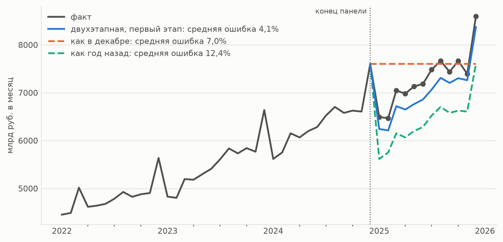

Совокупные потребительские расходы России по данным СберИндекса: факт (точки после пунктира — месяцы, которых модель не видела), прогноз первого этапа двухэтапной модели на год вперёд от конца панели и два ориентира — «как в декабре» (последнее значение на все месяцы) и «как год назад» (тот же месяц прошлого года). В легенде — средняя абсолютная ошибка за двенадцать месяцев.

Прогноз федерального агрегата от декабря 2024 против факта, млрд руб. в месяц. Ошибка — (прогноз − факт) / факт, в процентах: минус — прогноз ниже факта.

| месяц | факт | прогноз первого этапа | его ошибка, % | ошибка «как в декабре», % | ошибка «как год назад», % |
| --- | --- | --- | --- | --- | --- |
| январь 2025 | 6 491 | 6 242 | −3,8 | +17,1 | −13,5 |
| февраль 2025 | 6 468 | 6 212 | −4,0 | +17,5 | −11,1 |
| март 2025 | 7 047 | 6 718 | −4,7 | +7,9 | −12,7 |
| апрель 2025 | 6 980 | 6 649 | −4,7 | +8,9 | −13,1 |
| май 2025 | 7 132 | 6 761 | −5,2 | +6,6 | −13,1 |
| июнь 2025 | 7 184 | 6 859 | −4,5 | +5,8 | −12,5 |
| июль 2025 | 7 482 | 7 065 | −5,6 | +1,6 | −12,8 |
| август 2025 | 7 666 | 7 310 | −4,6 | −0,8 | −12,6 |
| сентябрь 2025 | 7 437 | 7 205 | −3,1 | +2,2 | −11,5 |
| октябрь 2025 | 7 665 | 7 303 | −4,7 | −0,8 | −13,6 |
| ноябрь 2025 | 7 394 | 7 261 | −1,8 | +2,8 | −10,7 |
| декабрь 2025 | 8 597 | 8 373 | −2,6 | −11,6 | −11,6 |
| средняя абсолютная ошибка, % |  |  | 4,1 | 7,0 | 12,4 |

Первый этап — бэктест выбрал для агрегата медианный по годам прирост того же месяца — ошибся за год в среднем на 4,1%, прогноз «как в декабре» — на 7,0%, «как год назад» — на 12,4%. На горизонтах 1, 3 и 6 месяцев — 3,8 / 4,2 / 4,5% против 17,1 / 14,2 / 10,6% и 13,5 / 12,4 / 12,7%. Прогноз ниже факта во всех 12 месяцах. Первый этап закладывает медианный за 2019–2024 годы прирост каждого месяца — в прогнозе это 10,1% декабрь к декабрю, а в 2023, 2024 и 2025 годах агрегат вырос на 17,8 / 14,5 / 13,1%. Это одна проверка на одном году: она показывает, что первый этап работает и вне бэктеста, но интервала не даёт.

**По муниципалитетам.** Простая панельная модель с долями категорий на январь 2025 даёт медианный рост к тому же месяцу прошлого года на 14,8% (у 80% рядов — от 8,2 до 21,2%); двухэтапная на год — рост суммы за 2025 год к сумме за 2024-й на 8,5% (у 80% рядов — от 5,9 до 10,4%). Сам агрегат вырос за год на 14,1%, а первый этап закладывал 9,5%: годовой прогноз по муниципалитетам наследует эту недооценку.

**Разнос опубликованного агрегата.** Федеральный индекс за 2025 год уже опубликован, а муниципального разреза нет, и прогнозировать можно только разнос: это делает `two_stage_known` — доли муниципалитетов по прошлым месяцам, умноженные на опубликованный агрегат; в файле её строки помечены `uses_published_aggregate`. Годовой рост по ней — 13,4% (у 80% рядов — от 9,2 до 16,3%). На истории этот режим выигрывает там, где панельной модели не хватает примеров: на год вперёд — 1 356 ₽ против 1 642 у двухэтапной. На месяц вперёд точнее простая панельная модель: 914 ₽ против 996, а при обучении от двадцати месяцев она точнее разноса на 3 фолдах из 4. На январь 2025 режимы расходятся заметно: медианный рост к тому же месяцу прошлого года — 22,1% у разноса против 14,8% у панельной модели; январей среди тестовых месяцев наукаста не было, и какой режим здесь точнее, покажет факт. Муниципальный прогноз относится к уже прошедшему году и будет проверен фактом, когда СберИндекс опубликует муниципальный разрез за 2025 год. Подробно о горизонтах — Пять горизонтов.

**УведомлениеСловарь терминов**

Раскройте, если какой-то термин в тексте окажется незнакомым. Всё по-русски и по существу, без отсылок к учебникам.

### Про данные

**Временной ряд** — последовательность значений одной величины по месяцам. У нас это расходы одного муниципалитета: 24 числа подряд.

**Панель** — много рядов сразу, наблюдаемых за один и тот же период. У нас 2190 муниципалитетов × 24 месяца.

**Лаг** — значение того же ряда несколько месяцев назад. «Лаг 3» — то, что было три месяца назад.

**ОКТМО** — общероссийский классификатор территорий муниципальных образований, официальный код территории. Нужен потому, что названия муниципалитетов неуникальны.

### Про то, как мы проверяем модели

**Горизонт прогнозирования** — на сколько месяцев вперёд предсказываем. У нас три.

**Обучающая и тестовая выборка** — первая часть ряда, по которой модель учится, и следующая за ней, по которой проверяется. Модель тестовую часть не видит.

**Фолд** — одно такое разбиение. Мы делаем три, каждый раз сдвигая границу вперёд.

**Скользящий origin с расширяющимся окном** — способ разбиения, при котором граница между обучением и тестом последовательно сдвигается, а обучающая часть растёт. Нужен потому, что единственное разбиение на 24 точках дало бы три тестовых значения на ряд — слишком мало, чтобы отличить качество модели от случайности.

**Подгонка под тест** — ошибка, при которой параметр подбирается по тем же данным, на которых потом измеряется качество. Результат выглядит лучше, чем есть, и на новых данных не воспроизводится. Мы дважды поймали себя на ней и оба раза пересчитали честно.

### Про метрики

**MAE** — средняя абсолютная ошибка: насколько в среднем прогноз промахивается, в рублях. Обязательна по условиям конкурса.

**MASE** — та же ошибка, поделённая на ошибку простейшего прогноза внутри обучающей части. Значение 1 означает «не лучше простейшего», 0,7 — «на 30% точнее». Нужна потому, что расходы по муниципалитетам различаются на порядок, и средний по панели MAE без неё перекошен в сторону крупных территорий.

**sMAPE** — ошибка в процентах от величины, не зависит от масштаба.

**R²** — доля разброса значений, которую модель объясняет: единица минус отношение суммы квадратов ошибок к SST — сумме квадратов отклонений факта от его среднего. В сводках R² считается по объединённому пулу тестовых точек всех рядов и фолдов, SST — вокруг среднего пула (**R² пул**). Рядом даётся медиана R² по парам ряд × фолд, где SST пары — вокруг среднего её тестового окна. Среднее R² по парам на трёх точках вырождено: почти ровное окно даёт SST около нуля и R² сколь угодно далеко ниже нуля, — поэтому в сводки оно не идёт.

**Доверительный интервал** — диапазон, в котором находится истинная величина эффекта. Если он накрывает ноль, эффект от нуля неотличим.

**Поправка на множественность (Бонферрони)** — ужесточение порога значимости, когда проверяется несколько гипотез сразу. Без неё из семи проверок одна пройдёт порог случайно, и её легко принять за находку.

### Про модели прогнозирования

**Наивная модель** — не оценка качества, а название класса: простейший прогноз без настройки параметров. «Оставить как в прошлом месяце» — наивная модель. Нужны как ориентир: модель, не бьющая наивную, бесполезна независимо от своей сложности.

**Сезонная наивная модель** — «повторить то, что было в этом месяце год назад».

**Дрейф** — продолжение прямой, проведённой через первое и последнее наблюдение.

**Экспоненциальное сглаживание (ETS)** — прогноз как взвешенное среднее прошлых значений, где недавние весят больше. **Затухающий тренд** — поправка, при которой рост со временем выдыхается, а не продолжается бесконечно.

**ARIMA** — классическая модель, описывающая ряд через его собственные прошлые значения и прошлые ошибки.

**Метод Тета** — простой метод, выигравший международное соревнование прогнозистов M3 и до сих пор остающийся крепким ориентиром на коротких рядах.

**Prophet** — модель от Meta, раскладывающая ряд на тренд, сезонность и праздники. В условиях конкурса упомянута как базовая.

**Градиентный бустинг** — ансамбль решающих деревьев, где каждое следующее исправляет ошибки предыдущих. **Гистограммный** — его быстрая разновидность.

**Глобальная модель** — одна модель, обученная на всех рядах панели сразу, вместо отдельной модели на каждый ряд. Идея в том, что похожие территории помогают друг другу.

**Фундаментальная модель временных рядов** — модель, заранее обученная на миллионах чужих рядов и применяемая без дообучения. **Zero-shot** — как раз режим «без дообучения».

**Ансамбль** — смесь прогнозов нескольких моделей.

### Про обнаружение структурных изменений

**Точка структурного изменения** — момент, после которого ряд ведёт себя иначе: сменился уровень, наклон или разброс. В русской статистической литературе это называют **разладкой** (от задачи о разладке Ширяева) — термин устоявшийся, но вне профессионального круга читается как «поломка», поэтому в тексте мы его не используем. Речь не об ошибках в данных, а о моментах, когда поведение ряда изменилось.

**PELT, BinSeg, Window, BottomUp, ядровой метод** — алгоритмы поиска таких точек. Первые работают с изменением среднего, ядровой — с изменением всего распределения. Сколько изломов в ряду, каждый решает сам: за каждый излом назначается **штраф**, и чем он больше, тем меньше изломов метод находит.

**CUSUM** — накопленная сумма отклонений от базового уровня; срабатывает, когда накопилось достаточно.

**Офлайновый и онлайновый режим** — метод видит ряд целиком и ищет изменение задним числом, либо идёт по ряду слева направо, зная только прошлое. Задача конкурса требует обнаруживать шоки «как можно раньше», а это свойство онлайнового режима.

**Полнота обнаружения** — доля настоящих структурных изменений, которые метод нашёл. **Ложная тревога** — срабатывание там, где изменения не было. **Запаздывание (задержка)** — на сколько месяцев позже настоящего момента метод поднял флаг. Считается только среди обнаруженных: у пропущенного изменения задержки нет.

**Врезка и позиция врезки** — возмущение известной величины, которое стенд вносит в настоящий ряд, и месяц, с которого оно начинается. Позиций несколько: при одной все задержки были бы измерены в одном месте ряда.

**Нетронутый близнец и парный зачёт** — тот же ряд стенда без врезки, при том же детекторе, режиме и штрафе. Сигнал испорченного ряда засчитывается обнаружением, только если близнец в тот же месяц молчит: если нетронутый ряд тревожит в тот же месяц, тревога была бы и без врезки (в `results/cp_bench.csv` — колонка `twin_flag_at_signal`).

**Граница задержки** — сигнал, пришедший позже заданного протоколом числа месяцев после врезки, обнаружением не считается: он говорит уже об изломе после врезки (колонка `late`).

**Сетка штрафов** — штрафы, на каждом из которых стенд гоняет методы со штрафом. Штраф для реальных данных выбирается по стенду правилом из конфига до прогона на них.

**Первый проверяемый месяц и эффект старта** — раньше минимальной истории детектор не запускается. В первый проверяемый месяц история у него самая короткая, и тревогу там поднимают все ряды, чей излом попал в первое окно: доля этого месяца завышена самим протоколом.

**Эпизод тревоги** — флаги ряда вместе с короткими перерывами между ними: эпизод кончается только после нескольких месяцев подряд без флага — стольких же, сколько излом считается недавним. Сигнал на панели — начало эпизода, так что один сдвиг даёт один сигнал.

**Ранговый вид и фон** — описание потокового сигнала, а не второй порог: место доли месяца события среди наблюдаемых месяцев и её отношение к фону — медиане долей месяцев без событий.

**J Юдена** — обнаружено минус ложных тревог, в процентных пунктах (TPR − FPR). Отрицательный J значит, что ложных тревог больше, чем обнаружений.

**Темп роста** — отношение значения к предыдущему. Переход к темпам роста убирает из ряда и тренд, и разницу масштабов между территориями.

## Данные

### Источник

Потребительские безналичные расходы на уровне муниципальных образований, [дашборд СберИндекса](https://sberindex.ru/ru/dashboards/potrebitelskie-beznalicnye-rashody-na-urovne-munizipalnyh-obrazovanij). Помесячно, январь 2023 — декабрь 2024, шесть категорий трат.

**Показать код**

```python
from src.data import load_panel, build_matrix
panel = load_panel("../data/raw/mo_spending_2023-2024.parquet")
wide, report = build_matrix(panel, "Все категории", max_gap=2)
print(report.as_text())
```

```
строк: 303126
МО: 2118 | категорий: 6 | периодов: 24
рядов всего: 2190
  без пропусков: 2016
  восстановлено интерполяцией: 12
  отброшено: 162
пропущенных ячеек в исходнике: 2039
```

### Ловушка: `mo` — это название, а не идентификатор

Наивный подсчёт уникальных значений колонки `mo` даёт 2118 и это неверная цифра. В России есть одноимённые муниципалитеты в разных регионах: «Октябрьский муниципальный район» существует в восьми, «Советский» — в пяти. Всего коллидируют 49 названий.

Колонки региона или ОКТМО в выгрузке нет — проверены оба формата, parquet и CSV содержат одни и те же десять колонок.

Разворот панели по имени склеивает разные муниципалитеты в один ряд и молча выбрасывает остальные. Ошибка не падает, не логируется и портит всё ниже по течению.

Восстановление опирается на структуру выгрузки: каждое МО хранится непрерывным блоком строк по возрастанию периода, значит новая сущность начинается там, где период перестал расти. Проверка сходится — 2190 сущностей в каждой из шести категорий, ровно столько муниципалитетов в выпадающем списке фильтра дашборда.

### Пропуски

Правило задано в конфигурации и одинаково для всех моделей: внутренний разрыв до двух месяцев чинится линейной интерполяцией, разрыв длиннее либо дыра на краю ряда — ряд исключается из оценки. Молчаливого `dropna` нет намеренно: судьба каждого ряда попадает в отчёт прогона, который напечатан выше.

Интерполяцией восстановлено 12 рядов из 2 028. Восстанавливается пропуск по всему ряду, а не по обучающей части фолда, то есть в строгом смысле с заглядыванием вперёд: соседний месяц, по которому достраивается точка, может лежать после origin, а у двух рядов восстановлены и сами тестовые месяцы фолда 1. Правило одно для всех моделей, и сравнение моделей это не искажает; строже было бы восстанавливать пропуски на каждом фолде по его обучающей части — так не делалось.

### Привязка к регионам

Регион и код ОКТМО восстановлены по [справочнику муниципальных образований СберИндекса](https://sberindex.ru/ru/research/dataset-borders-and-changes-of-municipalities) (лицензия CC BY-SA 4.0) для 2 042 рядов из 2 190.

Справочник версионный, и сопоставлять надо с записями, действовавшими в 2023–2024, а не с сегодняшними: фильтр по действующим выбрасывает городские округа Павловский Посад, Электрогорск и город Сасово, объединённые в 2024 году, — в нашем периоде они существовали.

**147 рядов с омонимичными названиями оставлены без региона намеренно.** В выгрузке нет ни ОКТМО, ни кода региона, различить их нечем, и приписать регион наугад означало бы поставить неверную подпись. Они участвуют в моделировании, поскольку для прогноза регион не нужен, но исключены из региональных разрезов.

Ещё один ряд в справочнике не найден вовсе — «внутригородская территория города федерального значения Александровский муниципальный округ»: такого названия в справочнике нет, и регион не приписывается. Итого 2 042 + 147 + 1 = 2 190 рядов выгрузки; на матрице моделирования — 1 891 + 136 + 1 = 2 028.

### Что выпало из оценки

Регионы, где из оценки выпало больше 30% рядов. Обрыв покрытия — ряд кончается раньше декабря 2024 (указан последний месяц с данными), «появляются позже» — начинается позже января 2023 (указан первый); оба края на месте — ряд выбросил внутренний разрыв длиннее двух месяцев.

| регион | рядов в выгрузке | выпало | что с выпавшими рядами |
| --- | --- | --- | --- |
| Республика Бурятия | 22 | 22 | обрыв покрытия — 22 (последний месяц: декабрь 2023) |
| Республика Дагестан | 11 | 11 | появляются позже — 10 (первый месяц: январь 2024 … декабрь 2024); есть только середина периода — 1 |
| Чеченская Республика | 5 | 5 | появляются позже — 5 (первый месяц: январь 2024 … ноябрь 2024) |
| Республика Ингушетия | 2 | 2 | обрыв покрытия — 2 (последний месяц: декабрь 2023) |
| Магаданская область | 9 | 6 | обрыв покрытия — 6 (последний месяц: май 2024 … ноябрь 2024) |
| Кабардино-Балкарская Республика | 9 | 5 | появляются позже — 4 (первый месяц: июль 2023 … декабрь 2024); внутренний разрыв длиннее двух месяцев — 1 |
| Чукотский автономный округ | 6 | 2 | обрыв покрытия — 1 (последний месяц: декабрь 2023); появляются позже — 1 (первый месяц: февраль 2023) |
| Амурская область | 23 | 7 | обрыв покрытия — 7 (последний месяц: декабрь 2023) |

Из 2 190 рядов выгрузки в оценку не вошли 162: обрыв покрытия — 82, появляются позже — 42, внутренний разрыв длиннее двух месяцев — 33 и есть только середина периода — 5; у 16 рядов с обрывом или поздним началом есть ещё и внутренний пропуск длиннее двух месяцев. Целиком выпали четыре региона: Республика Бурятия, Республика Дагестан, Республика Ингушетия и Чеченская Республика — по ним в оценке нет ни одного ряда. Это границы выгрузки, а не поведение потребителей: ряд, которого нет в данных часть периода, нельзя ни обучить, ни проверить на всех фолдах. Все модели, общий фактор, разложение ошибки и потоковый сигнал детекторов считаются только на этих 2 028 рядах (стенд обнаружения — на выборке 60 из них), поэтому сравнение от этих дыр не зависит, но на территории без рядов выводы работы не распространяются.

## Протокол оценки

Двадцать четыре точки на ряд делают выбор протокола не формальностью, а решением, от которого результат зависит сильнее, чем от выбора модели.

**Скользящий origin с расширяющимся окном.** Единственное разбиение на обучение и тест дало бы три тестовых значения на ряд — это шум, а не оценка. Origin сдвигается на горизонт:

| фолд | обучение | тест |
| --- | --- | --- |
| 0 | 1..15 | 16..18 |
| 1 | 1..18 | 19..21 |
| 2 | 1..21 | 22..24 |

**Насколько это важно.** Глобальная модель на фолдах 1–2 даёт MAE 1 006, а в среднем по всем трём — 1 466. Фолд с обучением в пятнадцать точек радикально тяжелее остальных — 2 387; три дополнительных месяца истории меняют качество сильнее, чем переход от наивной модели к градиентному бустингу.

**Метрики.** MAE обязательна по условиям конкурса. Рядом считаются R², sMAPE и MASE. MASE добавлена потому, что уровни расходов по муниципалитетам различаются на порядок — от примерно десяти тысяч рублей на человека до семидесяти четырёх, — и средний по панели MAE без неё перекошен в сторону крупных территорий.

**Как сводится MAE.** MAE ряда на фолде — средняя абсолютная ошибка по месяцам горизонта. Сводная MAE модели — простое среднее по всем парам ряд × фолд с весом один: усредняются территории, а не обороты, и крупный город весит столько же, сколько малый район. Но в рублях на человека ошибка больше там, где выше уровень расходов, и такие МО тянут среднее на себя, поэтому рядом стоит MASE: ошибка каждого ряда в ней поделена на среднюю ошибку прогноза «как в прошлом месяце» на его же обучающей части. R² сводится по объединённому пулу тестовых точек, а не как среднее R² рядов. В таблицах ниже MAE встречается ещё как среднее пофолдовых средних и как среднее на общих парах двух моделей; на основном протоколе все три способа дают одно число — отказов нет, и у каждой модели одни и те же 2 028 рядов на каждом фолде (расхождение меньше копейки). На горизонтах 6 и 12 модель может отказать на целом фолде: тогда её MAE по горизонту — по зачтённым фолдам, таблица пяти горизонтов это помечает, а прогон печатает предупреждение, если модели одного горизонта посчитаны на разных парах.

R² трёх моделей, сведённый тремя способами; строки — по MAE. Среднее и медиана — по парам ряд × фолд, SST каждой пары — вокруг среднего трёх её тестовых точек. Пул — один R² по всем тестовым точкам сразу, SST — вокруг среднего пула.

|  | MAE, ₽ | R² среднее | R² медиана | R² пул |
| --- | --- | --- | --- | --- |
| панельная + фактор + категории рядами | 1 217 | −21,411 | 0,306 | 0,978 |
| эталон конкурса (Prophet по умолчанию) | 1 581 | −10,619 | −0,566 | 0,961 |
| наивная: оставить как в прошлом месяце | 1 852 | −7,322 | −1,011 | 0,935 |

**Почему R² сводится пулом и медианой, а не средним.** Среднее R² по 6 084 парам ряд × фолд ставит три модели в порядке, обратном MAE: −7,3 у наивной, −10,6 у эталона и −21,4 у лучшей по MAE. R² пары считается по трём её тестовым точкам, SST — вокруг их же среднего, и где тест почти ровный, SST близка к нулю, а небольшой промах уводит R² далеко ниже нуля. На 10% пар с самым ровным тестом — где стандартное отклонение трёх точек, посчитанное с делением на n, не больше 1,2% их среднего, — приходится 90% суммы, из которой складывается среднее лучшей модели. На таких окнах выигрывает прогноз без движения: у наивной модели R² на них в среднем −60, у лучшей −193. Переворот — почти целиком эффект первого, календарно спокойного фолда, где и MAE ставит наивную модель первой — 805 против 1 096 у эталона и 1 641 у лучшей (см. таблицу по фолдам): на нём лежат 585 из 609 ровных пар и 99,6% суммы R² лучшей модели, а без него среднее идёт в порядке MAE: −1,71 у наивной, −1,32 у эталона и −0,12 у лучшей. Медиана к таким парам нечувствительна и порядок по MAE сохраняет: −1,01 у наивной, −0,57 у эталона и 0,31 у лучшей.

R² пул у всех трёх моделей близок к единице: 0,935 у наивной, 0,961 у эталона и 0,978 у лучшей. SST пула считается вокруг среднего всех тестовых точек: на разницу уровней между муниципалитетами приходится 95,7% этой суммы, на движение внутри тестовых окон — 2,7%, остальное — сдвиг уровня ряда от фолда к фолду. Почти всю разницу уровней объясняет уже последнее известное значение — R² пул наивной модели 0,935 при доле уровней 95,7%, и порядок по MAE пул сохраняет, но сжимает: у лучшей модели он выше, чем у наивной, на 0,043 при MAE ниже на 34,3%. Поэтому модели здесь сравниваются по MAE и MASE: они меряют промах в рублях и в долях ошибки простейшего прогноза на обучении и не делят его на движение внутри тестового окна. R² приводится, потому что его требует постановка задачи: превзойти базовую модель конкурса по MAE и R². По всем фолдам вместе лучшая модель обходит эталон и по пулу, и по медиане; по отдельности обходит на 2 фолдах из 3, как и по MAE: на первом, с самым коротким обучением, эталон впереди и по R² — пул 0,981 против 0,957, медиана −2,73 против −11,12.

**Пять горизонтов.** По уточнению организаторов та же конструкция разбиения применена отдельно к наукасту (горизонт 1) и горизонтам 3, 6 и 12; число фолдов на каждом — сколько допускают двадцать четыре точки: девять, три, два и один. Таблицы и разбор — в разделе Пять горизонтов.

## Базовая модель конкурса и ловушка годовой сезонности

Сравнение с эталоном приведено в разделе Результаты. Здесь — про настройку, на которой легко обжечься, и про то, как Prophet от неё защищается.

**Сначала о том, чего здесь нет.** Эталон конкурса не сломан и чинить его не требуется. Prophet по умолчанию задаёт `yearly_seasonality='auto'`, и эта логика сама выключает годовую сезонность, когда истории меньше 730 дней. Наши окна обучения — 425, 517 и 609 дней, то есть сезонность выключается на всех трёх фолдах. Больше того, на пятнадцати месяцах Prophet не включает вообще **ни одной** сезонной компоненты.

Проверено прямо: голый `Prophet()` и `Prophet(yearly_seasonality=False)` дают на наших рядах одинаковый прогноз с точностью до нуля. Поэтому строка `prophet` в таблице сравнения — это Prophet как есть, без единого нашего аргумента.

**Ловушка же вот в чём.** Практик, глядя на месячные данные, естественно рассуждает: месячные ряды — значит нужна годовая сезонность. Включает её явно — и получает следующее.

**Показать код**

```python
import logging, time
for name in ("prophet", "cmdstanpy"):
    logging.getLogger(name).setLevel(logging.CRITICAL)
from src.models.prophet_model import ProphetModel

y = wide["городской округ город Орёл"].to_numpy(float)
out, seconds = {}, {}
for label, kw in [("годовая включена насильно", dict(yearly_seasonality=True)),
                  ("Prophet по умолчанию", {})]:
    runs = []
    for _ in range(3):  # медиана трёх подгонок: время одной зависит от фона машины
        start = time.perf_counter()
        pred = ProphetModel(**kw).set_index(wide.index).fit(y[:15]).predict(3)
        runs.append(time.perf_counter() - start)
    out[label], seconds[label] = np.round(pred), float(np.median(runs))
out["факт"] = np.round(y[15:18])
pd.DataFrame(out, index=["месяц +1", "месяц +2", "месяц +3"])
```

|  | годовая включена насильно | Prophet по умолчанию | факт |
| --- | --- | --- | --- |
| месяц +1 | 38 261,00 | 32 321,00 | 32 071,00 |
| месяц +2 | −9 772,00 | 32 770,00 | 32 779,00 |
| месяц +3 | 38 741,00 | 33 233,00 | 33 252,00 |

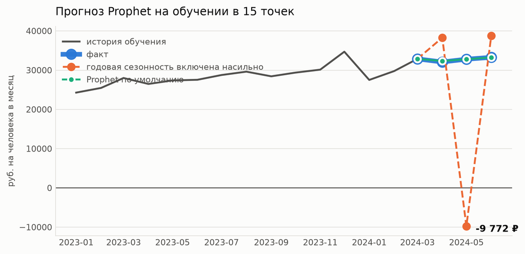

Один флаг конфигурации: зелёная линия — Prophet по умолчанию, почти совпадает с фактом; оранжевая — с насильно включённой годовой сезонностью — уходит в минус.

**И Prophet об этом предупреждает**: «Yearly seasonality is enabled with less than 730 days of history. The model may be under-identified, and the trend/seasonality decomposition can be unstable **and dependent on the Prophet/Stan version**» — то есть результат ещё и невоспроизводим между машинами. Предупреждение точное, и то, что библиотека выводит его сама, а по умолчанию и вовсе не даёт себе включить сезонность на такой истории, — это Prophet в плюс, а не в минус.

Недоопределённость проявляется дважды. Статистически — приведённым прогнозом. Вычислительно — стоимостью подгонки: на ряде Орла подгонка с насильной сезонностью длится 4,5 с против 0,04 с у настроек по умолчанию — в 107 раз дольше (медиана трёх подгонок при сборке этого отчёта; кратность — на одном ряде, а не на панели). Полнопанельный прогон с насильной сезонностью шёл 20 202 секунды, настройки по умолчанию на тех же рядах и фолдах — 141 секунду (журналы прогонов 26.09), но во время первого прогона машине не хватало памяти, и кратность по этому времени мы не считаем.

**Как это попало в таблицу.** Обе конфигурации считаются как отдельные модели: `prophet` — эталон конкурса, `prophet_forced_yearly` — та же модель с насильно включённой сезонностью. Вторая нужна не для сравнения, а как измеренная цена ошибки настройки. На полной панели эта цена — MAE 22 527 ₽ против 1 581 ₽ у эталона, в 14,3 раза больше, и R² пул −9,19: ниже нуля, то есть хуже, чем прогноз одним средним значением.

## Сравнение моделей прогнозирования

**Показать код**

```python
summary = table("../results/summary.csv", index_col=0)
# Колонка сводки → заголовок, знаков после запятой, «+» у выигрыша. Колонки,
# которой в файле нет, нет и в таблице.
_columns = {
    "MAE": ("MAE, ₽", 0, False),
    "MASE": ("MASE", 2, False),
    "sMAPE": ("sMAPE, %", 1, False),
    "R² пул": ("R² пул", 3, False),
    "R² медиана": ("R² медиана", 2, False),
    "к Prophet, %": ("к Prophet, %", 1, True),
    "к наивной, %": ("к наивной, %", 1, True),
    "серий": ("серий", 0, False),
    "отказов": ("отказов", 0, False),
}
if "MAE" in summary:
    _ranked_sum = summary.sort_values("MAE")
    _shown = pd.DataFrame({
        title: _ranked_sum[column].map(lambda v: num(v, digits, sign))
        for column, (title, digits, sign) in _columns.items() if column in _ranked_sum
    })
    _shown.index.name = None
_shown if "MAE" in summary else summary
```

Сравнение моделей на основном протоколе: горизонт 3, три фолда, полная панель; строки — по MAE. MASE — ошибка в долях от ошибки одношагового наивного прогноза внутри обучения, sMAPE — в процентах от величины. R² пул — один R² по всем тестовым точкам сразу, R² медиана — по парам ряд × фолд. Выигрыш «к Prophet» и «к наивной» — по MAE, в процентах от MAE эталона конкурса и наивной модели; плюс — лучше. Серий — ряды, по которым модель дала прогноз, отказов — пары ряд × фолд без прогноза.

|  | MAE, ₽ | MASE | sMAPE, % | R² пул | R² медиана | к Prophet, % | к наивной, % | серий | отказов |
| --- | --- | --- | --- | --- | --- | --- | --- | --- | --- |
| global_gbm_stack_factor | 1 217 | 0,62 | 4,0 | 0,978 | 0,31 | +23,0 | +34,3 | 2 028 | 0 |
| global_gbm_factor | 1 236 | 0,63 | 4,1 | 0,973 | 0,15 | +21,8 | +33,3 | 2 028 | 0 |
| global_gbm_region | 1 266 | 0,64 | 4,3 | 0,971 | 0,19 | +19,9 | +31,6 | 2 028 | 0 |
| global_gbm_cat | 1 273 | 0,64 | 4,1 | 0,977 | −0,19 | +19,5 | +31,3 | 2 028 | 0 |
| global_gbm_all | 1 277 | 0,65 | 4,3 | 0,974 | −0,36 | +19,2 | +31,1 | 2 028 | 0 |
| global_gbm_stack | 1 326 | 0,67 | 4,3 | 0,976 | 0,36 | +16,1 | +28,4 | 2 028 | 0 |
| two_stage | 1 393 | 0,75 | 4,5 | 0,974 | −0,40 | +11,9 | +24,8 | 2 028 | 0 |
| global_gbm | 1 466 | 0,73 | 4,7 | 0,970 | −0,13 | +7,3 | +20,9 | 2 028 | 0 |
| global_gbm_pretrain | 1 473 | 0,76 | 4,8 | 0,967 | −0,45 | +6,8 | +20,5 | 2 028 | 0 |
| global_gbm_news | 1 490 | 0,74 | 4,8 | 0,968 | −0,09 | +5,7 | +19,5 | 2 028 | 0 |
| two_stage_news | 1 500 | 0,80 | 4,8 | 0,970 | −1,08 | +5,1 | +19,0 | 2 028 | 0 |
| prophet | 1 581 | 0,84 | 5,1 | 0,961 | −0,57 | 0,0 | +14,7 | 2 028 | 0 |
| ets_damped | 1 675 | 0,89 | 5,5 | 0,954 | −0,69 | −6,0 | +9,6 | 2 028 | 0 |
| ets_seasonal | 1 690 | 0,89 | 5,6 | 0,959 | −0,28 | −6,9 | +8,8 | 2 028 | 0 |
| chronos_ft | 1 830 | 0,97 | 6,0 | 0,957 | −0,56 | −15,8 | +1,2 | 2 028 | 0 |
| naive_last | 1 852 | 1,01 | 6,0 | 0,935 | −1,01 | −17,2 | 0,0 | 2 028 | 0 |
| arima011 | 1 896 | 1,03 | 6,2 | 0,933 | −1,01 | −19,9 | −2,3 | 2 028 | 0 |
| drift | 1 901 | 1,02 | 6,1 | 0,942 | −1,28 | −20,3 | −2,6 | 2 028 | 0 |
| arima111 | 1 905 | 1,02 | 6,1 | 0,936 | −1,23 | −20,5 | −2,8 | 2 028 | 0 |
| global_gbm_ext | 1 934 | 0,97 | 6,2 | 0,946 | −0,03 | −22,3 | −4,4 | 2 028 | 0 |
| theta | 1 949 | 1,03 | 6,5 | 0,943 | −0,97 | −23,3 | −5,2 | 2 028 | 0 |
| chronos_ft_base | 2 004 | 1,05 | 6,7 | 0,954 | −1,38 | −26,8 | −8,2 | 2 028 | 0 |
| timesfm | 2 120 | 1,12 | 7,0 | 0,937 | −1,14 | −34,1 | −14,4 | 2 028 | 0 |
| moirai | 2 268 | 1,18 | 7,4 | 0,929 | −1,19 | −43,5 | −22,5 | 2 028 | 0 |
| two_stage_sa | 2 448 | 1,28 | 7,9 | 0,915 | −1,82 | −54,9 | −32,2 | 2 028 | 0 |
| chronos_base_log | 2 451 | 1,30 | 8,2 | 0,918 | −2,14 | −55,1 | −32,3 | 2 028 | 0 |
| chronos_base | 2 462 | 1,31 | 8,2 | 0,917 | −2,19 | −55,8 | −32,9 | 2 028 | 0 |
| chronos_small_log | 2 598 | 1,39 | 8,6 | 0,907 | −2,81 | −64,3 | −40,2 | 2 028 | 0 |
| chronos_panel | 2 620 | 1,40 | 8,6 | 0,905 | −2,93 | −65,7 | −41,4 | 2 028 | 0 |
| chronos_small | 2 620 | 1,40 | 8,6 | 0,905 | −2,93 | −65,7 | −41,4 | 2 028 | 0 |
| seasonal_drift | 3 817 | 2,01 | 13,0 | 0,868 | −8,95 | −141,5 | −106,1 | 2 028 | 0 |
| seasonal_naive | 4 404 | 2,31 | 15,0 | 0,825 | −11,67 | −178,6 | −137,7 | 2 028 | 0 |
| prophet_forced_yearly | 22 527 | 12,10 | 69,8 | −9,190 | −215,62 | −1 325,1 | −1 116,1 | 2 028 | 0 |

`chronos_panel` и `chronos_small` — одна и та же модель, Chronos-Bolt small, вызванный пакетно и по рядам: ошибки по рядам расходятся не больше чем на 0,006 ₽. Поэтому различных моделей в таблице 32, и в тексте счёт идёт по ним.

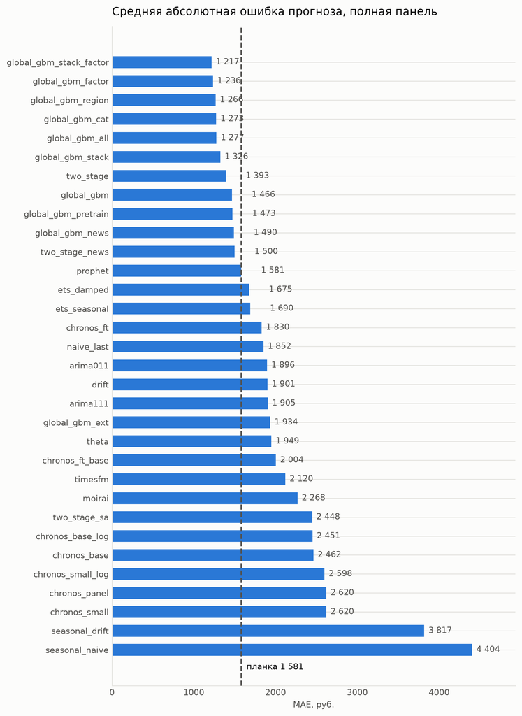

Планка — эталон конкурса, Prophet с настройками по умолчанию. Классические модели сбиты в плотную группу справа от неё. Prophet с насильно включённой годовой сезонностью на график не вынесен: его ошибка так велика, что остальные столбцы сжались бы у нуля; его строка — в таблице выше.

### Что из этого следует

Классические подходы — экспоненциальное сглаживание, ARIMA, метод Тета — расположились плотной группой и ни один не дотянулся до эталона. Это не слабость конкретных алгоритмов, а **потолок подхода «моделируем каждый ряд отдельно»**: пятнадцати точек недостаточно для оценки параметров, сколько их ни выжимай.

Отсюда следовало, где искать оставшийся выигрыш — не в более сложной модели одного ряда, а в информации между рядами.

### Глобальная модель

Почему она выигрывает — разобрано в разделе Результаты. Здесь то, как она устроена.

**Целевая переменная — отношение будущего значения к последнему известному.** Не уровень. Это ставит территории разного масштаба в одинаковые условия и заодно снимает вопрос о смещении абсолютного уровня показателя: постоянный множитель в отношении сокращается.

**Прямой прогноз на каждый горизонт.** Для каждого шага обучается своя модель, а не одна с рекурсивной подстановкой собственных прогнозов: на горизонте в три шага прямой подход точнее и не накапливает ошибку.

**Признаки.** Отношения к лагам за 2–6 месяцев, логарифм текущего уровня, скользящие среднее и разброс за 3 и 6 месяцев, месяц года. Лаг 12 намеренно отсутствует: он требует одиннадцати точек истории, и при обучении в 15 точек на горизонт 3 не остаётся ни одного обучающего примера.

**Почему не LightGBM.** Он требует системной библиотеки OpenMP, которой на чистой macOS нет, и запуск у проверяющего упирается в установку пакета через менеджер системы. Для воспроизводимости такая зависимость того не стоит. Взят гистограммный бустинг из scikit-learn: алгоритм тот же, зависимость уже есть.

## Пять горизонтов: наукаст и 1, 3, 6, 12 месяцев

Организаторы в ответе от 24 сентября уточнили постановку: сравнить модели для наукастинга и ещё как минимум на четырёх горизонтах — 1, 3, 6 и 12 месяцев. Вся работа выше сделана на горизонте 3. Здесь та же конструкция разбиения — скользящий origin с расширяющимся окном, шаг равен горизонту — применена к каждому горизонту отдельно (`configs/horizons.yaml`, `scripts/horizons.py`). Столбец горизонта 3 в таблицах ниже — это ровно те три фолда, что и в остальном отчёте.

Числа в нём совпадают с остальным отчётом до рубля у 12 из 13 моделей, которые есть и там. Расходится только «Chronos-Bolt, дообученный» — 1 835 здесь против 1 830 в основной таблице: это ещё одна реализация дообучения, и реализации разобраны в разделе о фундаментальных моделях.

**Что здесь называется наукастом.** Внутримесячных данных в панели нет, поэтому наукаст месяца t — это прогноз по данным до t−1, то есть горизонт 1. В узком смысле слова наукаст на месячных данных от прогноза на месяц не отличается, и мы не делаем вид, что отличается. Один способ отличить всё же есть. Федеральный индекс потребительских расходов СберИндекс публикует регулярно и с коротким лагом, а муниципальный разрез выложен разово, к конкурсу; в настоящей задаче наукаста агрегат за текущий месяц уже известен, когда муниципальных значений ещё нет, и прогнозировать надо только разнос. Строка «разнос известного агрегата» считает ровно это: доли по прошлому, как у двухэтапной модели, а множитель — опубликованное значение. На горизонте 1 это наукаст. На горизонтах длиннее — уже оракул: общее движение страны на весь горизонт считается известным, и в ошибке остаётся межрядовая часть. Это та самая нижняя граница из разложения ошибки, только построенная заранее, а не вычтенная задним числом. Строгой границей она не является: правило оценки доли по-прежнему выбирается внутренним бэктестом, и на первом фолде горизонта 3 оно выбрано иначе, чем у прогнозной модели, — 1 021 против 781. Это единственная модель в проекте, которая читает ряд после origin, и делает она это по условию задачи, а не по недосмотру.

| горизонт | фолдов | обучение | тест |
| --- | --- | --- | --- |
| 1, наукаст | 9 | 15, 16, …, 23 | месяцы 16..24 по одному |
| 3 | 3 | 15, 18, 21 | основной протокол |
| 6 | 2 | 12, 18 | 13..18 и 19..24 |
| 12 | 1 | 12 | 13..24, весь 2024 год |

**Во что упирается протокол на двадцати четырёх точках.** На горизонте 12 фолд ровно один, обучение — двенадцать месяцев, доверительного интервала нет и быть не может. Число фолдов задаёт и длину обучения в первом из них, поэтому на горизонтах 6 и 12 приходится начинать с двенадцати месяцев, а на 1 и 3 первый origin тот же, что в основном протоколе. Прямая многошаговая стратегия панельного бустинга на горизонте 12 не имеет обучающих примеров по построению: чтобы обучить модель шага 7 на двенадцати месяцах, нужна пара «момент t и месяц t+7» внутри обучения, а с учётом шести лагов признаков её нет. Мы не чиним это костылём вроде рекурсивной подстановки, а фиксируем как результат: отказ модели попадает в таблицу прочерком.

Протокол вскрыл и ошибку в самой панельной модели, которая на основном разбиении не проявлялась: набор признаков запоминался один на все шаги горизонта, а при двенадцати месяцах обучения у шага 6 всего одна обучающая пара, и в ней ещё нет сдвига долей категорий. Модель шага 1 получала шестнадцать колонок вместо двадцати одной. Исправлено — колонки хранятся по шагам; на трёх фолдах основного протокола числа не изменились ни на рубль.

MAE по горизонтам, полная панель. Прочерк — модель на этом горизонте не имеет обучающих примеров; в скобках — сколько фолдов горизонта модель посчитала, если не все.

|  | h = 1, фолдов: 9 | h = 3, фолдов: 3 | h = 6, фолдов: 2 | h = 12, фолдов: 1 |
| --- | --- | --- | --- | --- |
| наивная: оставить как в прошлом месяце | 1 611 | 1 852 | 2 632 | 2 691 |
| сезонно-наивная: как год назад | 4 404 | 4 404 | 4 076 | 4 076 |
| эталон конкурса (Prophet по умолчанию) | 1 550 | 1 581 | 2 137 | 2 722 |
| двухэтапная: одно число и разнос долями | 1 018 | 1 393 | 1 749 | 1 642 |
| двухэтапная с новостной поправкой | 1 070 | 1 500 | 1 985 | 1 878 |
| разнос известного агрегата: наукаст, дальше оракул | 996 | 1 263 | 1 405 | 1 356 |
| панельная модель, без внешних источников | 969 | 1 466 | 4 307 | — |
| панельная + доли категорий | 914 | 1 273 | 4 263 | — |
| панельная + фактор + категории рядами | 839 | 1 217 | 1 442 | — |
| панельная + новостные темы регионов | 971 | 1 490 | 4 338 | — |
| Chronos-Bolt, дообученный | 1 994 | 1 835 | 3 450 (1 из 2 фолдов) | — |
| Chronos-Bolt small, zero-shot | 2 026 | 2 620 | 2 972 | 4 021 |
| TimesFM 2.5 200M, zero-shot | 1 685 | 2 120 | 2 430 | 3 477 |
| Moirai 1.1-R small, zero-shot | 1 953 | 2 268 | 3 936 | 2 580 |

MASE по горизонтам: ошибка в долях от ошибки одношагового наивного прогноза внутри обучения. Больше единицы — хуже, чем «оставить как есть» на один шаг.

|  | h = 1, фолдов: 9 | h = 3, фолдов: 3 | h = 6, фолдов: 2 | h = 12, фолдов: 1 |
| --- | --- | --- | --- | --- |
| наивная: оставить как в прошлом месяце | 0,89 | 1,01 | 1,57 | 1,72 |
| сезонно-наивная: как год назад | 2,38 | 2,31 | 2,40 | 2,64 |
| эталон конкурса (Prophet по умолчанию) | 0,85 | 0,84 | 1,24 | 1,69 |
| двухэтапная: одно число и разнос долями | 0,55 | 0,75 | 1,04 | 1,05 |
| двухэтапная с новостной поправкой | 0,58 | 0,80 | 1,17 | 1,20 |
| разнос известного агрегата: наукаст, дальше оракул | 0,54 | 0,66 | 0,81 | 0,87 |
| панельная модель, без внешних источников | 0,50 | 0,73 | 2,73 | — |
| панельная + доли категорий | 0,48 | 0,64 | 2,66 | — |
| панельная + фактор + категории рядами | 0,46 | 0,62 | 0,87 | — |
| панельная + новостные темы регионов | 0,51 | 0,74 | 2,76 | — |
| Chronos-Bolt, дообученный | 1,07 | 0,97 | 1,83 (1 из 2 фолдов) | — |
| Chronos-Bolt small, zero-shot | 1,11 | 1,40 | 1,72 | 2,60 |
| TimesFM 2.5 200M, zero-shot | 0,93 | 1,12 | 1,46 | 2,29 |
| Moirai 1.1-R small, zero-shot | 1,08 | 1,18 | 2,23 | 1,64 |

R² пул по горизонтам: один R² по всем тестовым точкам горизонта, SST — вокруг среднего пула. Прочерк — у модели на этом горизонте нет обучающих примеров.

|  | h = 1, фолдов: 9 | h = 3, фолдов: 3 | h = 6, фолдов: 2 | h = 12, фолдов: 1 |
| --- | --- | --- | --- | --- |
| наивная: оставить как в прошлом месяце | 0,953 | 0,935 | 0,895 | 0,898 |
| сезонно-наивная: как год назад | 0,825 | 0,825 | 0,833 | 0,833 |
| эталон конкурса (Prophet по умолчанию) | 0,961 | 0,961 | 0,933 | 0,894 |
| двухэтапная: одно число и разнос долями | 0,985 | 0,974 | 0,960 | 0,962 |
| двухэтапная с новостной поправкой | 0,984 | 0,970 | 0,950 | 0,954 |
| разнос известного агрегата: наукаст, дальше оракул | 0,986 | 0,977 | 0,971 | 0,972 |
| панельная модель, без внешних источников | 0,986 | 0,970 | 0,737 | — |
| панельная + доли категорий | 0,987 | 0,977 | 0,747 | — |
| панельная + фактор + категории рядами | 0,989 | 0,978 | 0,969 | — |
| панельная + новостные темы регионов | 0,985 | 0,968 | 0,729 | — |
| Chronos-Bolt, дообученный | 0,939 | 0,957 | 0,831 (1 из 2 фолдов) | — |
| Chronos-Bolt small, zero-shot | 0,942 | 0,905 | 0,867 | 0,782 |
| TimesFM 2.5 200M, zero-shot | 0,959 | 0,937 | 0,916 | 0,848 |
| Moirai 1.1-R small, zero-shot | 0,936 | 0,929 | 0,792 | 0,907 |

На горизонте 1 медиана R² не определена по построению — в тестовом окне одна точка, и SST вокруг среднего окна равна нулю, — а R² пул определён: он считается по всем тестовым точкам горизонта сразу.

**Оговорка к таблицам горизонтов.** На горизонте 6 «Chronos-Bolt, дообученный» посчитан на 2 028 парах ряд × фолд против 4 056 у остальных: фолда с обучением 12 мес. у него нет, и его MAE и R² пул — только по фолду с обучением 18 мес. Сравнивать такое число со столбцом можно лишь с этой поправкой.

**Наукаст.** Лучшая связка даёт **839 рублей** против 1 550 у эталона — выигрыш 45,9%, вдвое больше, чем на горизонте 3. Эталон же на горизонте 1 обходит наивную модель всего на 3,8%: на один месяц вперёд «оставить как есть» почти так же хорошо, как тренд Prophet. Девять фолдов делают видимым то, что три прятали: ошибка любой модели без сезонности определяется тем, какой месяц выпал в тест. Декабрьский фолд — 5 728 у наивной и 4 634 у эталона против 902 у базовой панельной модели и 1 143 у двухэтапной. Панельная модель к декабрю 2024-го уже видела один декабрь в обучении; двухэтапная знает его из федерального ряда, где декабрей шесть.

Наукаст (горизонт 1) по фолдам. В шапке — длина обучения в месяцах; тестовый месяц на один больше.

|  | 15 | 16 | 17 | 18 | 19 | 20 | 21 | 22 | 23 |
| --- | --- | --- | --- | --- | --- | --- | --- | --- | --- |
| наивная: оставить как в прошлом месяце | 780 | 741 | 863 | 984 | 695 | 2 425 | 1 605 | 680 | 5 728 |
| сезонно-наивная: как год назад | 4 791 | 4 409 | 4 751 | 4 456 | 4 459 | 3 765 | 4 451 | 3 848 | 4 705 |
| эталон конкурса (Prophet по умолчанию) | 881 | 932 | 985 | 1 133 | 979 | 2 283 | 991 | 1 132 | 4 634 |
| двухэтапная: одно число и разнос долями | 651 | 657 | 717 | 661 | 1 111 | 2 068 | 1 245 | 908 | 1 143 |
| двухэтапная с новостной поправкой | 926 | 675 | 797 | 673 | 1 193 | 2 198 | 1 079 | 1 061 | 1 025 |
| разнос известного агрегата: наукаст, дальше оракул | 553 | 699 | 778 | 786 | 843 | 1 845 | 1 412 | 833 | 1 221 |
| панельная модель, без внешних источников | 2 351 | 689 | 842 | 905 | 684 | 828 | 783 | 733 | 902 |
| панельная + доли категорий | 1 937 | 672 | 941 | 770 | 636 | 841 | 738 | 839 | 855 |
| панельная + фактор + категории рядами | 537 | 672 | 729 | 674 | 674 | 893 | 1 303 | 760 | 1 307 |
| панельная + новостные темы регионов | 2 471 | 674 | 779 | 881 | 686 | 836 | 776 | 750 | 888 |
| Chronos-Bolt, дообученный | 2 977 | 1 508 | 979 | 993 | 611 | 2 847 | 1 791 | 920 | 5 324 |
| Chronos-Bolt small, zero-shot | 1 380 | 1 508 | 1 704 | 1 815 | 1 178 | 1 613 | 1 791 | 1 046 | 6 202 |
| TimesFM 2.5 200M, zero-shot | 1 331 | 1 832 | 1 328 | 1 411 | 1 049 | 1 381 | 985 | 682 | 5 166 |
| Moirai 1.1-R small, zero-shot | 781 | 960 | 1 002 | 1 021 | 808 | 2 224 | 4 187 | 687 | 5 904 |

**Известный агрегат почти ничего не добавляет на месяц вперёд.** 996 против 1 018 у прогнозного варианта — 21,4 рубля. Движение страны на один месяц предсказуемо из её собственной сезонности, и знать его точно почти не нужно. Оставшаяся тысяча — межрядовый разброс, тот самый, который в разложении ошибки не двигается ни одной из шести моделей, для которых посчитано разложение. Наукаст в узком смысле упирается в него же.

**На длинных горизонтах панельные модели теряют обучающие примеры, и остаётся двухэтапная.** На горизонте 6 базовая панельная модель при двенадцати месяцах обучения даёт 7 200 — это левый край развёртки по длине обучения, воспроизведённый на другом горизонте, — а перенос сезонности возвращает её к 1 845, ровно как развёртка и предсказывала.

На горизонте 12 панельных моделей не остаётся вовсе, и **лучшая — двухэтапная модель: 1 642 против 2 691 у наивной и 2 722 у эталона**, точнее их на 39% и 40%. Оба ориентира обходят ещё «двухэтапная с новостной поправкой» (1 878) и «Moirai 1.1-R small, zero-shot» (2 580) — у фундаментальных моделей это единственный такой случай на всех горизонтах, и держится он на одном фолде. Оракул агрегата на том же горизонте даёт 1 356: даже точно зная движение страны на год вперёд, этим правилом долей точнее 1 356 не разнести. Строгой нижней границей это число не является — правило долей выбирается бэктестом, см. оговорку в начале раздела.

Длинные горизонты по фолдам. Обучение 12 месяцев — единственный origin, с которого горизонт 12 вообще возможен.

|  | h = 6, обучение 12 | h = 6, обучение 18 | h = 12, обучение 12 |
| --- | --- | --- | --- |
| наивная: оставить как в прошлом месяце | 3 253 | 2 011 | 2 691 |
| сезонно-наивная: как год назад | 3 872 | 4 281 | 4 076 |
| эталон конкурса (Prophet по умолчанию) | 2 399 | 1 875 | 2 722 |
| двухэтапная: одно число и разнос долями | 1 835 | 1 662 | 1 642 |
| двухэтапная с новостной поправкой | 1 858 | 2 112 | 1 878 |
| разнос известного агрегата: наукаст, дальше оракул | 1 249 | 1 560 | 1 356 |
| панельная модель, без внешних источников | 7 200 | 1 414 | — |
| панельная + доли категорий | 6 756 | 1 770 | — |
| панельная + фактор + категории рядами | 1 845 | 1 040 | — |
| панельная + новостные темы регионов | 7 302 | 1 373 | — |
| Chronos-Bolt, дообученный | — | 3 450 | — |
| Chronos-Bolt small, zero-shot | 2 493 | 3 450 | 4 021 |
| TimesFM 2.5 200M, zero-shot | 2 540 | 2 321 | 3 477 |
| Moirai 1.1-R small, zero-shot | 2 965 | 4 908 | 2 580 |

Сезонно-наивная модель здесь показывает, в чём именно состоит выигрыш. «Как год назад» на горизонте 12 — это 4 076, худший результат таблицы: 2024 год лежит на пятнадцать-двадцать процентов выше 2023-го, и повтор прошлого года систематически занижает. Двухэтапная модель — это тот же сезонный рисунок, только взятый из федерального ряда и умноженный на его же годовой рост. На двенадцати месяцах вся её сила в этом множителе.

**Подтверждает ли таблица закон про длину ряда?** Частично, и оговорка здесь обязательна: в такой конструкции горизонт и длина обучения движутся вместе. Горизонты 6 и 12 начинаются с двенадцати месяцев обучения, поэтому «разрыв растёт с горизонтом» и «разрыв растёт с укорочением истории» в первом фолде неразличимы. Чисто можно сказать три вещи. При равном обучении в восемнадцать месяцев переход от горизонта 3 к горизонту 6 увеличивает ошибку наивной модели с 1 218 до 2 011, лучшей панельной — с 845 до 1 040: разрыв между ними растёт с 373 до 971. При двенадцати месяцах перенос — единственное, что удерживает панельную модель от развала, и это прямое предсказание развёртки. И двухэтапная модель держится в коридоре 1 000–1 750 на всех четырёх горизонтах, тогда как наивная уходит с 1 611 на 2 691. На самых же длинных обучениях наукаста — 21, 22 и 23 месяца — связка с переносом проигрывает базовой панельной модели (1 303, 760, 1 307 против 783, 733, 902): правый край развёртки на другом горизонте.

**Ошибка растёт не с расстоянием от origin, а с календарём.** Средняя по горизонту цифра прячет это, поэтому ниже ошибка по каждому шагу от одного origin.

Ошибка по шагам горизонта от origin в декабре 2023 (обучение 12 месяцев, горизонт 12). Шаг 1 — январь 2024, шаг 12 — декабрь 2024.

|  | 1 | 2 | 3 | 4 | 5 | 6 | 7 | 8 | 9 | 10 | 11 | 12 |
| --- | --- | --- | --- | --- | --- | --- | --- | --- | --- | --- | --- | --- |
| наивная: оставить как в прошлом месяце | 7 036 | 4 567 | 1 820 | 2 366 | 2 083 | 1 644 | 1 360 | 1 211 | 2 656 | 1 412 | 1 436 | 4 705 |
| сезонно-наивная: как год назад | 2 316 | 3 188 | 3 776 | 4 791 | 4 409 | 4 751 | 4 456 | 4 459 | 3 765 | 4 451 | 3 848 | 4 705 |
| эталон конкурса (Prophet по умолчанию) | 4 455 | 2 571 | 1 340 | 1 880 | 2 063 | 2 085 | 2 135 | 2 228 | 3 971 | 3 301 | 3 724 | 2 911 |
| двухэтапная: одно число и разнос долями | 2 429 | 833 | 1 245 | 1 043 | 1 136 | 1 091 | 1 293 | 1 765 | 3 175 | 2 332 | 1 948 | 1 418 |
| двухэтапная с новостной поправкой | 2 429 | 2 232 | 2 537 | 1 184 | 1 136 | 1 091 | 1 293 | 1 765 | 3 175 | 2 332 | 1 948 | 1 418 |
| разнос известного агрегата: наукаст, дальше оракул | 2 102 | 827 | 1 161 | 1 104 | 1 161 | 1 142 | 1 220 | 1 306 | 2 387 | 1 374 | 1 365 | 1 119 |
| Chronos-Bolt small, zero-shot | 4 883 | 2 158 | 1 532 | 1 385 | 2 036 | 2 966 | 4 218 | 4 961 | 3 045 | 4 852 | 5 118 | 11 093 |
| TimesFM 2.5 200M, zero-shot | 4 594 | 1 706 | 1 837 | 1 889 | 2 180 | 3 033 | 3 783 | 3 881 | 2 329 | 3 664 | 3 780 | 9 044 |
| Moirai 1.1-R small, zero-shot | 5 818 | 3 527 | 1 480 | 2 174 | 2 205 | 2 122 | 2 081 | 2 051 | 1 788 | 1 316 | 1 358 | 5 037 |

То же от origin в июне 2024 (обучение 18 месяцев, горизонт 6). Шаг 1 — июль, шаг 6 — декабрь.

|  | 1 | 2 | 3 | 4 | 5 | 6 |
| --- | --- | --- | --- | --- | --- | --- |
| наивная: оставить как в прошлом месяце | 984 | 1 265 | 1 404 | 1 102 | 1 341 | 5 973 |
| сезонно-наивная: как год назад | 4 456 | 4 459 | 3 765 | 4 451 | 3 848 | 4 705 |
| эталон конкурса (Prophet по умолчанию) | 1 133 | 1 178 | 2 015 | 1 211 | 1 448 | 4 268 |
| двухэтапная: одно число и разнос долями | 661 | 1 169 | 2 930 | 1 946 | 1 742 | 1 526 |
| двухэтапная с новостной поправкой | 673 | 1 149 | 3 344 | 2 750 | 2 279 | 2 476 |
| разнос известного агрегата: наукаст, дальше оракул | 786 | 1 212 | 2 755 | 1 617 | 1 587 | 1 403 |
| панельная модель, без внешних источников | 905 | 1 112 | 1 367 | 1 279 | 1 786 | 2 034 |
| панельная + доли категорий | 770 | 1 153 | 1 359 | 1 164 | 4 431 | 1 745 |
| панельная + фактор + категории рядами | 669 | 783 | 1 009 | 946 | 1 167 | 1 663 |
| панельная + новостные темы регионов | 881 | 1 100 | 1 306 | 1 235 | 1 778 | 1 939 |
| Chronos-Bolt, дообученный | 1 815 | 2 545 | 1 008 | 2 726 | 3 265 | 9 342 |
| Chronos-Bolt small, zero-shot | 1 815 | 2 545 | 1 008 | 2 726 | 3 265 | 9 342 |
| TimesFM 2.5 200M, zero-shot | 1 411 | 1 832 | 732 | 1 555 | 1 615 | 6 782 |
| Moirai 1.1-R small, zero-shot | 3 786 | 4 321 | 2 029 | 3 785 | 4 857 | 10 668 |

От декабря 2023-го наивная модель ошибается на 7 036 в январе, на 1 211 в августе и на 4 705 в декабре: восьмой шаг вперёд точнее первого в шесть раз. Ошибка — функция не расстояния, а того, какой месяц прогнозируется: январь и декабрь — сезонные развороты, и модель без сезонности промахивается на них на любом расстоянии. У эталона та же форма плюс уход тренда осенью: 3 301–3 971 на шагах с девятого по одиннадцатый. У двухэтапной модели январь стоит 2 429, февраль-июль — около тысячи, а сентябрь — 3 175. Сентябрь тяжёл и для оракула, 2 387: в этом месяце сдвинулись сами доли территорий, единственное место в году, где двигалась межрядовая часть.

От июня 2024-го, с восемнадцатью месяцами обучения, лучшая панельная модель растёт с шагом мягко — 669 на первом, 1 663 на шестом, и шестой шаг — снова декабрь. У наивной модели пять шагов держатся в пределах 984–1 404, а шестой даёт 5 973.

**Что из этого следует.** Для наукаста и горизонта 3 — панельная модель с переносом при коротком обучении и простая панельная при длинном, как и сказано в разделе о практике. Для горизонта 6 — та же связка, если обучения хотя бы двенадцать месяцев. Для горизонта 12 на этих данных выбор — двухэтапная модель, и это не компромисс: она обходит эталон на сорок процентов и опирается на 61 месяц федеральной истории вместо двенадцати муниципальных. Рекомендация, стало быть, зависит от горизонта ровно в той же мере, что и от длины истории, и это одна и та же зависимость.

**Дообученный Chronos на горизонтах.** На наукасте — 1 994, хуже наивной модели и эталона (1 611 и 1 550): у наивной он выигрывает на 2 фолдах из 9, а декабрь промахивает почти так же, как она, — 5 324 против 5 728. Наукаст не даётся ни одной фундаментальной модели: TimesFM — 1 685, Moirai — 1 953, Chronos без дообучения — 2 026, все хуже наивной. На горизонте 3 — 1 835: ещё одна реализация дообучения, все они сведены в разделе о фундаментальных моделях. Дальше дообучение упирается в длину обучения: ему нужны окно контекста, окно цели и проверочное окно по времени, так что обучение должно быть длиннее трёх горизонтов. При обучении 18 мес. и горизонте 6 нет ни одного обучающего окна с целью до проверочного: дообучение пропускается, модель остаётся zero-shot и даёт 3 450 против 2 011 у наивной на том же фолде. На фолдах наукаста с обучением 16 и 21 мес. дообучение совпало с zero-shot: ранняя остановка вернула исходную модель. При обучении 12 мес. — на горизонтах 6 и 12 — отказ, и он в таблице прочерком.

## Перенос с длинных рядов

Двадцать четыре точки на ряд — корневое ограничение всей работы, и обойти его внутри панели нечем. Собственный муниципальный набор СберИндекса ровно такой же длины, более ранних данных по муниципалитетам не существует. Зато в том же каталоге лежат федеральные ряды за семь-девять лет, собранные той же методикой по тем же транзакциям.

### Чего именно не хватает короткому ряду

Видно на первом фолде. Обучение кончается мартом 2024-го, прогнозируем апрель-июнь. Признаки требуют шести точек истории, поэтому целевыми месяцами в обучении оказываются только июль-декабрь 2023-го и январь-март 2024-го.

| горизонт | целевые месяцы в обучении | прогнозируем месяц |
| --- | --- | --- |
| h = 1 | 7, 8, 9, 10, 11, 12, 1, 2, 3 | 4 |
| h = 2 | 8, 9, 10, 11, 12, 1, 2, 3 | 5 |
| h = 3 | 9, 10, 11, 12, 1, 2, 3 | 6 |

Апреля, мая и июня в обучении нет ни разу. Панельная модель физически не может знать, что происходит с расходами в апреле, — а федеральный ряд к этому моменту видел пять апрелей.

### Пять конструкций переноса, работают две

Длинные ряды федеральные: в месяце *t* значение одно и то же для всех 2028 муниципалитетов. Это определяет, что с ними можно сделать, а что нельзя.

| конструкция | MAE | Δ к базовой, ₽ | 95% ДИ | доля выигранных пар |
| --- | --- | --- | --- | --- |
| общий фактор + категории рядами | 1 217,03 | −249,07 | [−268; −230] | 59% |
| общий фактор (федеральная эластичность) | 1 235,71 | −230,40 | [−245; −216] | 62% |
| общий фактор (эластичность по регионам) | 1 266,23 | −199,88 | [−214; −186] | 62% |
| доли категорий как признаки | 1 273,07 | −193,03 | [−209; −177] | 65% |
| общий фактор + доли категорий | 1 276,84 | −189,26 | [−209; −169] | 56% |
| категории как отдельные обучающие ряды | 1 325,61 | −140,49 | [−154; −127] | 59% |
| базовая, без внешних источников | 1 466,10 | 0,00 | [0; 0] | 0% |
| предобучение на отраслевых рядах | 1 472,53 | 6,43 | [−16; +29] | 50% |
| длинные ряды как внешние регрессоры | 1 933,51 | 467,41 | [+451; +484] | 30% |

**Как внешние регрессоры — хуже на треть.** Темпы роста федеральных рядов, добавленные к признакам модели, ухудшают прогноз резко и однозначно. Причина структурная, а не алгоритмическая: признак, одинаковый для всех рядов в момент *t*, различает не муниципалитеты, а моменты времени, и на обучающей части фолда принимает ровно столько значений, сколько там моментов.

| признак | различных значений в обучении | диапазон обучения | значение при прогнозе | вне диапазона |
| --- | --- | --- | --- | --- |
| consumer-spending_d1 | 9 | [−0,154; +0,151] | +0,069 |  |
| consumer-spending_d12 | 9 | [+0,157; +0,198] | +0,184 |  |
| consumer-spending_d3 | 9 | [−0,039; +0,158] | −0,073 | да |
| izmenenie-obema-fot_d1 | 9 | [−0,273; +0,416] | +0,121 |  |
| izmenenie-obema-fot_d12 | 9 | [+0,148; +0,212] | +0,237 | да |
| izmenenie-obema-fot_d3 | 9 | [−0,078; +0,472] | −0,146 | да |
| key_rate_real_d1 | 9 | [+0,003; +1,771] | +0,003 | да |
| key_rate_real_d12 | 9 | [−1,790; +5,510] | +5,517 | да |
| key_rate_real_d3 | 9 | [−0,003; +3,599] | +0,321 |  |
| median-wages_d1 | 9 | [−0,084; +0,147] | +0,015 |  |
| median-wages_d12 | 9 | [+0,116; +0,222] | +0,179 |  |
| median-wages_d3 | 9 | [−0,079; +0,224] | −0,075 |  |
| oboroty-biznesa_d1 | 9 | [−0,250; +0,179] | +0,114 |  |
| oboroty-biznesa_d12 | 9 | [+0,095; +0,279] | +0,225 |  |
| oboroty-biznesa_d3 | 9 | [−0,130; +0,184] | −0,104 |  |

Девять значений на всю обучающую часть — это метка месяца, а не регрессор. Треть признаков при прогнозе выходит за диапазон обучения, и дереву приходится экстраполировать, чего деревья не умеют в принципе: за крайним разрезом лист отдаёт константу. Отсюда и величина провала.

**Предобучение — ноль.** Модель сначала учится предсказывать отношение на 56 отраслевых рядах длиной до 116 месяцев, затем дообучается на панели тем же ансамблем. Разница с базовой моделью неотличима от нуля, доверительный интервал накрывает ноль с запасом. Форма динамики отрасли переносится на муниципалитет хуже, чем хотелось бы: у отрасли нет ни масштаба муниципалитета, ни его структуры трат, а общее между ними — ровно сезонность, которую дешевле взять фактором.

**Общий фактор — работает.** Конструкция другая: длинная история используется не как признак, а как способ узнать то, чего в панели нет.

1. Модель федерального ряда выбирается **бэктестом на его собственной истории до origin** — отбор идёт по прошлому, подгонкой под тест не является. На всех трёх фолдах выигрывает медианный по годам сезонный прирост; сезонное сглаживание, ETS, SARIMA и усреднение кандидатов проигрывают ему.
2. Прогноз федерального фактора переводится в фактор панели эластичностью, оценённой на обучающих месяцах. Панель подвижнее страны: эластичность около 1,3, то есть на федеральный рост в процент панель отвечает третью процента сверху.
3. Эластичность **сжимается** в долю дисперсии фактора, которую прогноз реально объясняет по внутреннему бэктесту. Прогноз шумный, и коэффициент, оценённый по точным значениям, при подстановке шумных систематически переусиливал бы поправку. Сжатие получилось 0,79–0,87.

**Эластичность по регионам — не помогает, и это понятно.** Регионы действительно различаются: от 1,01 у Татарстана до 2,12 у Якутии, и характеристика устойчивая — оценки по первой и второй половине периода коррелируют на 0,77. Но эластичность умножает не только сигнал, но и ошибку прогноза фактора. Якутия с коэффициентом 2,1 получает вдвое большую поправку и вдвое большую ошибку, когда прогноз промахнулся. При точности прогноза фактора около 85% усиление в среднем во вред.

### Категории как обучающие ряды, а не как признаки

Доли категорий описывают муниципалитет, но числа обучающих пар не меняют. Есть второй ход с теми же данными: подать шесть категорий как **отдельные обучающие ряды**. Пар становится вшестеро больше — 12 168 рядов вместо 2 028.

Покрытие календарных месяцев при этом то же самое: апреля в обучении первого фолда по-прежнему нет. Меняется другое — у категорий **разные сезонные рисунки**. Общепит живёт летом, продовольствие декабрём. Модель, которой показали только итог, заучивает конкретные переходы одного ряда; модель, которой показали шесть разных рисунков, вынуждена опираться на признаки, а не на память о прошлом декабре.

Это лучшая из всех конструкций: 1 217 в сочетании с общим фактором. Но оценивать её по среднему — значит пропустить главное.

### Как это выглядит по фолдам и по длине обучения

Зависимость выигрыша от длины обучения, измеренная на десяти её значениях, оказалась главным результатом работы — она разобрана в разделе Результаты вместе с разложением ошибки, которое объясняет механизм, и с таблицей по фолдам. Здесь — только парные разницы к базовой модели внутри каждого фолда: по ним видно, у каких источников форма одна и та же, а не только у лучшего.

|  | фолд 0 | фолд 1 | фолд 2 |
| --- | --- | --- | --- |
| длинные ряды как внешние регрессоры | +1 092 [+1 071; +1 113] | −99 [−112; −86] | +409 [+387; +432] |
| предобучение на отраслевых рядах | −662 [−694; −629] | +33 [+8; +57] | +648 [+611; +686] |
| доли категорий как признаки | −529 [−551; −506] | −34 [−70; +2] | −16 [−27; −6] |
| общий фактор (эластичность по регионам) | −406 [−441; −370] | −215 [−230; −199] | +21 [+12; +29] |
| общий фактор (федеральная эластичность) | −556 [−591; −521] | −177 [−190; −164] | +41 [+35; +48] |
| категории как отдельные обучающие ряды | −275 [−292; −259] | −357 [−384; −330] | +211 [+193; +230] |
| общий фактор + категории рядами | −746 [−781; −712] | −283 [−310; −255] | +281 [+263; +300] |

Отрицательное число означает, что источник помогает. У четырёх источников из семи форма одна: на первых двух фолдах они помогают, на третьем — мешают, потому что на самом длинном обучении модель уже знает месяцы сама. Доли категорий как признаки помогают по знаку на всех трёх фолдах, на втором — в пределах шума, на третьем — лишь на 16 ₽. Знака не держат длинные ряды как внешние регрессоры (на первом фолде +1 092 ₽) и предобучение на отраслевых рядах (на втором фолде +33 ₽).

### Что переносится на самом деле

Выигрывают ровно те конструкции, где внешний источник отвечает на вопрос, на который короткий ряд ответить не может: **какова сезонная форма месяца, которого в обучении не было**. Общий фактор отвечает на него федеральной историей, категории рядами — шестью разными сезонными рисунками вместо одного.

Как источник дополнительных признаков тот же самый длинный ряд бесполезен или вреден. Различие не в данных, а в конструкции, и это главный вывод раздела.

### Категории трат: то, чего федеральные ряды не умеют

Отдельный источник, устроенный ровно наоборот. В панели шесть категорий расходов на каждое муниципальное образование, а прогнозируем мы только «Все категории». Остальные пять — это признаки, которые **различаются между муниципалитетами**, чего ни один федеральный ряд не даёт.

Берутся именно доли и их изменение, а не уровни: «Все категории» включает остальные пять по определению, и уровень категории почти линейно связан с уровнем итога — в отношениях он выродился бы в копию уже имеющегося признака. Доля говорит о структуре: где половина расходов идёт на продовольствие, динамика другая, чем там, где столько же приходится на маркетплейсы. Пять категорий покрывают около 72% итога, остаток приходится на прочее.

Выигрыш сопоставим с общим фактором, хотя источник информации совершенно другой. **Складывать их, однако, не получается**: комбинация хуже одного фактора. Похоже, структура трат частично улавливала ту же общую сезонность, и когда фактор убирает её из цели, категории добавляют уже в основном шум.

### Сколько тут на самом деле определённости

Парные интервалы в таблице конструкций узкие, а пофолдовые — по t с 2 степенями свободы — накрывают ноль у всех восьми конструкций. Почему обе оценки верны и отвечают на разные вопросы — в сравнении с эталоном, где те же два интервала посчитаны против Prophet.

## Обнаружение точек структурных изменений

### Чем мерить методы, если разметки нет

Размеченных разладок в муниципальных расходах не существует. Стенд сравнения построен так (протокол — `configs/changepoints.yaml`, код — `src/cp_bench.py`, прогон — `scripts/changepoints.py`).

**Потоковый протокол.** Задача требует выявлять шоки «как можно раньше». «Раньше» — свойство онлайнового режима: офлайновый метод, видящий ряд целиком, на вопрос о своевременности не отвечает вовсе. Поэтому все методы, включая офлайновые, гоняются в расширяющемся окне: в момент `t` детектор получает только историю до `t` и поднимает флаг, если нашёл излом среди трёх последних точек; первый флаг — сигнал. Раньше восьми точек детектор не запускается: первый проверяемый месяц — сентябрь 2023. Сигнал до врезки возмущения — ложная тревога, и такое возмущение обнаруженным не считается.

**Зачёт — в паре с нетронутым близнецом и с границей задержки.** Сигнал не раньше врезки засчитывается обнаружением при двух условиях. Первое: сигнал пришёл не позже чем через три месяца после врезки: столько же излом считается недавним, и более поздний сигнал говорит уже об изломе после врезки. Второе: в месяц сигнала не тревожит нетронутый близнец испорченного ряда — тот же ряд без врезки при том же детекторе, режиме и штрафе: если нетронутый ряд тревожит в тот же месяц, тревога была бы и без врезки; вето — точно по месяцу, флаг близнеца в соседнем месяце сигнал не снимает. Сигнал ряда — всегда его первый флаг: поздний или снятый близнецом первый сигнал — пропуск, следующий флаг не ищется, как не искал бы его оператор, увидевший первую тревогу. В `results/cp_bench.csv` у каждой строки две колонки зачёта: `late` — сигнал позже границы и `twin_flag_at_signal` — у близнеца флаг в месяц сигнала (пишется и без правила); сводки считают, сколько сигналов сняло каждое правило, — `n late` и `n twin-vetoed`. Счётчики не пересекаются: засчитанные вместе с ними дают все сигналы не раньше врезки. Задержка — месяцы от врезки до засчитанного сигнала — становится сопоставимым числом для всех методов.

**Неизвестное число изломов.** Все шесть методов сами решают, есть ли излом: пять — при штрафе за каждый излом, на сетке из шести штрафов — 0,5; 1; 1,5; 2; 3 и 5, CUSUM — своим порогом. Ещё до первой версии стенда части методов задавался ровно один излом — это сегментация при известном числе изломов, а не обнаружение. Но ложные тревоги на сырых рядах были не её артефактом: при неизвестном числе изломов и штрафе 5 они остаются на уровне 53,3–73,3% нетронутых рядов у методов со штрафом и 100% у CUSUM — их дают сами сырые ряды (ниже).

**Синтетика поверх настоящего шума.** В 60 случайных рядов панели вносятся возмущения трёх типов — сдвиг уровня, сдвиг наклона и рост разброса — величиной 1, 2 и 4σ, где σ — стандартное отклонение месячных приращений ряда, в сентябре 2023, марте 2024, июне 2024 и сентябре 2024: при одной позиции врезки все задержки были бы измерены в одном месте ряда. Декабря и января среди месяцев врезки нет: врезка в месяц сезонного скачка засчитала бы обнаружением сам скачок — так вышло в первой версии стенда. Разметка верна по построению, а шум, сезонность и масштаб — настоящие.

**Ряды без структурных изменений.** Каждый ряд выборки проходит стенд и нетронутым: там любая тревога — ложная. Без таких рядов таблица показывала бы только полноту и молчала о точности. Обнаружение и ложные тревоги сводятся в одно число — J Юдена, обнаружено минус ложных: ниже нуля — ложных тревог больше, чем обнаружений. «Ложная» здесь значит «не вызванная врезкой»: ряды настоящие, со своими скачками, и к этому мы вернёмся ниже.

### Главный результат: решает преобразование, а не алгоритм

Стенд при штрафе, выбранном правилом до реальных данных, и CUSUM со своим порогом. Обнаружено — доля возмущений, сигнал о которых засчитан по правилам зачёта (раздел выше); задержка — в месяцах и только среди обнаруженных; «задержка 0» — доля обнаруженных в месяц врезки; ложных — доля нетронутых рядов с тревогой; J Юдена — обнаружено минус ложных.

| подготовка ряда | детектор | штраф | обнаружено, % | задержка, медиана, мес. | задержка 0, % обнаруженных | ложных на чистых, % | J Юдена |
| --- | --- | --- | --- | --- | --- | --- | --- |
| темпы роста | PELT | 5 | 13,9 | 3 | 4,3 | 0,0 | +13,9 |
|  | BinSeg | 5 | 13,9 | 3 | 4,3 | 0,0 | +13,9 |
|  | BottomUp | 5 | 11,9 | 3 | 0,0 | 0,0 | +11,9 |
|  | ядровой (RBF) | 5 | 4,7 | 3 | 12,9 | 0,0 | +4,7 |
|  | Window | 5 | 3,8 | 3 | 0,0 | 0,0 | +3,8 |
|  | CUSUM | свой порог | 20,1 | 1 | 42,1 | 58,3 | −38,2 |
| сырые значения | BottomUp | 5 | 28,0 | 2 | 10,6 | 53,3 | −25,3 |
|  | PELT | 5 | 35,3 | 1 | 20,4 | 66,7 | −31,3 |
|  | BinSeg | 5 | 35,0 | 1 | 20,6 | 66,7 | −31,7 |
|  | Window | 5 | 30,8 | 2 | 0,8 | 73,3 | −42,5 |
|  | ядровой (RBF) | 5 | 20,9 | 2 | 2,2 | 66,7 | −45,8 |
|  | CUSUM | свой порог | 18,9 | 1 | 48,3 | 100,0 | −81,1 |
| без профиля месяца | ядровой (RBF) | 5 | 20,5 | 2 | 0,9 | 55,0 | −34,5 |
|  | BottomUp | 5 | 19,7 | 2 | 4,5 | 76,7 | −57,0 |
|  | PELT | 5 | 23,9 | 1 | 17,0 | 90,0 | −66,1 |
|  | BinSeg | 5 | 23,9 | 1 | 17,1 | 90,0 | −66,1 |
|  | Window | 5 | 15,7 | 2 | 3,5 | 90,0 | −74,3 |
|  | CUSUM | свой порог | 23,6 | 1 | 46,8 | 100,0 | −76,4 |

Один и тот же PELT на сырых значениях тревожит на 66,7% нетронутых рядов, на темпах роста — на 0%; J Юдена −31,3 → +13,9. Так у всех шести: на сырых значениях J отрицателен у каждого (от −81,1 до −25,3) — тревога на нетронутом ряде случается чаще, чем обнаружение на испорченном, — а на темпах роста у пяти методов со штрафом он положителен (от +3,8 до +13,9; ложных у них при штрафе 5 нет, и J — сама доля обнаружения, а в ней у каждого 64,4–79,7% засчитанного — сигналы в декабре, ниже). Разброс J между ними — 10,1 пункта, выигрыш каждого от смены преобразования — от 37,2 до 50,5: решает преобразование, а не алгоритм. Причина — сезонность и структура самих сырых рядов, а не структурные изменения. Декабрьский скачок расходов (у медианного муниципалитета +17,6% в 2023 и +18,0% в 2024 году) на сырых рядах выглядит как сдвиг уровня, но он лишь одна из причин. Из 256 первых тревог на нетронутых сырых рядах на декабрь 2023 – февраль 2024 приходятся 68, на первый проверяемый месяц, сентябрь 2023, — 21; чаще всего первая тревога — в декабре 2023 у BottomUp и CUSUM, в мае 2024 у PELT, BinSeg и ядрового (RBF) и в июне 2024 у Window.

Обнаружение при переходе к темпам роста падает — у PELT с 35,3% до 13,9%, — но на сырых значениях ложных тревог больше, чем обнаружений, а правило близнеца снимает там 173 сигнала: в тот же месяц тревожит и нетронутый ряд. Абсолютный уровень и на темпах роста скромный: лучший J — +13,9 у самого PELT и столько же у BinSeg, но без сигналов в декабре PELT находит 4,6% (ниже). CUSUM со своим порогом и на темпах роста тревожит на 58,3% нетронутых рядов (J −38,2).

Режим с вычитанием среднего профиля месяца даёт 55–100% ложных тревог. Причина: на двух годах истории на каждый месяц приходится максимум одно прошлое наблюдение, и профиль оценивается по одной точке. Приводим как отрицательный результат.

Штраф ядрового метода с остальными несопоставим — стоимость считается в пространстве ядра, — поэтому он откалиброван по нетронутым рядам стенда на темпах роста (`results/cp_calibration.csv`): для каждого номинального штрафа берётся штраф ядра, при котором доля ложных тревог ближе всего к PELT, при равенстве — меньший. При штрафе 5 это 2,789: 0% ложных тревог против 0% у PELT; при штрафах 0,5 и 1 калибровка упёрлась в край сетки — ложных тревог у ядра 100%, у PELT 100%. На сырых значениях и без профиля месяца ядро сопоставимо с PELT лишь по построению на темпах роста.

Штраф для реальных данных выбран по стенду до их прогона — правилом из конфига: наибольший J Юдена у PELT на темпах роста среди штрафов сетки, при равенстве меньший (таблица ниже). Выбран штраф 5 с J +13,9 — наибольший в сетке, так что лучший штраф мог лежать и за её краем; лог прогона отмечает это строкой «ВНИМАНИЕ». Ложных тревог при нём нет ни у одного метода со штрафом на темпах роста — ниже нуля им падать некуда, — и J равен доле обнаружения: за краем сетки J мог бы вырасти, только если вырастет само обнаружение. Из 400 сигналов PELT на темпах роста, пришедших не раньше врезки, засчитано 300, граница задержки сняла 100, правило близнеца — ни одного: нетронутый близнец при этом штрафе не тревожит ни разу. Действие правила близнеца видно на более мягких штрафах: при 3 оно снимает 71 сигнал, при 2 — 132.

PELT на темпах роста на всей сетке штрафов — по этим строкам правило выбирает штраф для реальных данных. Без сигналов в декабре — доля обнаруженных, если не считать засчитанных сигналов, пришедших на декабрь (ниже). Снято — сигналы не раньше врезки, не прошедшие правила зачёта (раздел выше); счётчики не пересекаются.

| штраф | обнаружено, % | без сигналов в декабре, % | ложных на чистых, % | J Юдена | снято: позже границы | снято: близнец |
| --- | --- | --- | --- | --- | --- | --- |
| 0,5 | 7,6 | 7,5 | 100,0 | −92,4 | 6 | 370 |
| 1 | 10,5 | 9,3 | 100,0 | −89,5 | 49 | 293 |
| 1,5 | 16,3 | 12,9 | 90,0 | −73,7 | 114 | 225 |
| 2 | 27,8 | 17,7 | 56,7 | −28,8 | 165 | 132 |
| 3 | 24,9 | 13,8 | 26,7 | −1,8 | 144 | 71 |
| 5 — выбран | 13,9 | 4,6 | 0,0 | +13,9 | 100 | 0 |

PELT на темпах роста при выбранном штрафе — по величине возмущения, в долях σ. Ложные тревоги от величины не зависят: они считаются по нетронутым рядам.

| величина возмущения | обнаружено, % | задержка, медиана, мес. | задержка 0, % обнаруженных | ложных на чистых, % | J Юдена |
| --- | --- | --- | --- | --- | --- |
| 1σ | 5,7 | 3 | 0,0 | 0,0 | +5,7 |
| 2σ | 13,2 | 3 | 1,1 | 0,0 | +13,2 |
| 4σ | 22,8 | 3 | 7,3 | 0,0 | +22,8 |

PELT на темпах роста находит возмущение в 2σ с медианной задержкой 3 месяца, в 1,1% случаев — в месяц врезки; всего находит 13,2% таких возмущений. С величиной растёт и доля найденных в месяц врезки: 0 → 1,1 → 7,3% от 1σ к 4σ — крупный сдвиг чаще виден сразу.

Нулевая задержка возможна — 4,3% обнаружений у PELT на темпах роста. Механизм у неё настоящий: правило засчитывает любой излом среди трёх последних точек, а детектор, увидев выброс в конце окна, ставит излом «у конца» раньше, чем может его точно датировать: отрезок после излома не бывает короче минимальной длины. Сигнал «здесь что-то изменилось» приходит раньше, чем точная дата излома.

PELT на темпах роста при выбранном штрафе — по месяцу врезки возмущения (`results/cp_summary_by_position.csv`). Задержка — только среди обнаруженных. Снято — сигналы не раньше врезки, не прошедшие правила зачёта (раздел выше).

| врезка | обнаружено, % | задержка, медиана, мес. | задержка 0, % обнаруженных | снято: позже границы | снято: близнец |
| --- | --- | --- | --- | --- | --- |
| сентябрь 2023 | 9,4 | 3 | 0,0 | 11 | 0 |
| март 2024 | 5,9 | 1 | 18,8 | 25 | 0 |
| июнь 2024 | 3,0 | 2 | 12,5 | 64 | 0 |
| сентябрь 2024 | 37,2 | 3 | 2,5 | 0 | 0 |

PELT на темпах роста при выбранном штрафе: обнаружено, % — по виду возмущения и месяцу врезки (разрез `results/cp_bench.csv`).

| врезка возмущение | сентябрь 2023 | март 2024 | июнь 2024 | сентябрь 2024 |
| --- | --- | --- | --- | --- |
| сдвиг уровня | 0,0 | 1,1 | 0,0 | 0,0 |
| сдвиг наклона | 21,1 | 1,7 | 1,7 | 85,0 |
| рост разброса | 7,2 | 15,0 | 7,2 | 26,7 |

**Обнаружение по позициям несопоставимо**, и дело не в том, что один месяц врезки сам по себе «легче» другого: у каждой позиции своё устройство стенда вокруг неё. Сентябрь 2023 — первый проверяемый месяц: при врезке в него детектор до врезки не запускается ни разу, а при врезке в марте 2024, июне 2024 и сентябре 2024 успевает сделать 6, 9 и 12 проверок. Поэтому на поздних позициях часть испорченных рядов может поднять тревогу ещё до врезки, а первый сигнал до врезки — не обнаружение: при штрафе 5 таких рядов нет ни на одной позиции, при штрафе 3 — 21,7% при врезке в марте 2024, 23,3% при врезке в июне 2024 и 23,3% при врезке в сентябре 2024. Сдвиг наклона задан так, что к концу ряда дорастает до 3σ × величину, откуда бы ни начался, поэтому чем позже врезка, тем он круче: при врезке в сентябре 2024 — в 5 раз круче, чем в сентябре 2023. Окно засчитывания — месяц врезки и три месяца после него — при врезке в сентябре 2023 и сентябре 2024 кончается декабрём, при врезке в марте 2024 и июне 2024 декабря в нём нет. По видам (таблица выше): сдвиг уровня — 0–1,1% по позициям (в темпах роста это разовый выброс в месяц врезки, а не новый уровень); сдвиг наклона при врезке в сентябре 2024 находится в 85% случаев, при остальных — 1,7–21,1%; рост разброса — 7,2–26,7% по позициям. Наклон при врезке в сентябре 2024 по построению самый крутой (выше), но и сигнал у 123 из 153 этих обнаружений приходит в декабре 2024 (при врезке в сентябре 2023 — у всех 38 обнаружений наклона, в декабре 2023): крутизну, декабрь и конец панели эти числа не разделяют, и доля 85% между ними не делится.

**67% обнаружений PELT на темпах роста при штрафе 5 — сигналы в декабре.** Из 300 засчитанных на декабрь приходятся 201: 49 — на декабрь 2023, от врезки в сентябре 2023 с задержкой 3 месяца; 152 — на декабрь 2024, от врезки в сентябре 2024 с задержкой 3 месяца. Без сигналов в декабре PELT находит 4,6% возмущений, а не 13,9%; при штрафе 3, выбранном в первой версии стенда, сигналов в декабре — 239 из 538 (44,4%). Протокол v2 убрал врезку в самый декабрь и тревоги, общие с нетронутым близнецом, — то, что в первой версии засчитывало обнаружением саму сезонность, — но декабрь остался в окне засчитывания двух позиций из четырёх. Отчего сигнал приходит в декабре, по позициям видно не одинаково. При врезке в сентябре 2023 на декабрь 2023 приходятся 49 из 51 засчитанных; наклон там самый пологий, а сдвиг наклона находится в 21,1% случаев против 1,7% при врезке в марте 2024 и июне 2024, где наклон круче, а декабря в окне нет: по-видимому, декабрьский скачок здесь добавляется к врезке. При врезке в сентябре 2024 на декабрь 2024 приходятся 152 из 201 засчитанных, но декабрь 2024 — ещё и последний месяц панели, а наклон при этой врезке в 5 раз круче, чем при врезке в сентябре 2023, — декабрь ли здесь переводит врезку через порог, эти числа не отделяют от конца панели и крутизны наклона. Это описание тех же строк стенда, а не новый критерий: обнаружение в таблицах раздела остаётся числом протокола, а без декабрьских сигналов оно показано рядом (таблица штрафов выше).

То же описание — для всех методов сразу. Если не засчитывать ни одному из них сигналы, пришедшие на декабрь (ложные тревоги считаются по нетронутым рядам и не меняются), правило выбрало бы тот же штраф 5 — J PELT на темпах роста без декабря +4,6, наибольший на сетке, — и тезис держится по тому же условию: разброс J методов со штрафом на темпах роста, 3,6 пункта, меньше наименьшего выигрыша от смены преобразования, 35,6.

### Первая версия стенда и почему её переделали

В первой версии стенда — протокол v1, `configs/changepoints_v1.yaml`, результаты — `results/cp_v1/` — врезки стояли в декабре 2023, марте 2024 и июне 2024, сетка штрафов была 1 и 3, а сигнал не раньше врезки засчитывался обнаружением без границы задержки и без нетронутого близнеца. Правило выбора было тем же и выбрало штраф 3. В таблице — PELT на темпах роста при нём рядом с протоколом v2.

PELT на темпах роста: первая версия стенда при выбранном тогда штрафе (`results/cp_v1/cp_summary.csv`) и протокол v2 — при выбранном штрафе и при том же штрафе, что был выбран в v1. Снято — сигналы не раньше врезки, которые v2 не засчитал по своим правилам зачёта (раздел выше); у v1 этих правил не было.

|  | v1, штраф 3 — выбран тогда | v2, штраф 5 — выбран | v2, штраф 3 — как в v1 |
| --- | --- | --- | --- |
| обнаружено, % | 32,6 | 13,9 | 24,9 |
| задержка, медиана, мес. | 2 | 3 | 3 |
| задержка 0, % обнаруженных | 25,0 | 4,3 | 9,9 |
| ложных на чистых, % | 26,7 | 0,0 | 26,7 |
| J Юдена | +5,9 | +13,9 | −1,8 |
| снято: позже границы | — | 100 | 144 |
| снято: близнец | — | 0 | 71 |

**Врезка в декабре 2023 совпала с декабрьским скачком расходов**, и обнаружением засчитывался сам скачок. PELT на сырых значениях при этой врезке находил 65–68,3% возмущений при любом их типе и величине, а на темпах роста на неё пришлись 97 из 132 нулевых задержек, и в 58 из них нетронутый близнец ряда тревожил в тот же месяц. Без декабрьской врезки у PELT на темпах роста доля нулевой задержки — 11,8% вместо 25%, обнаружение — 27,5% вместо 32,6%, J Юдена — +0,8 вместо +5,9, а J методов со штрафом на темпах роста — от −6,3 до +9,1 (со всеми врезками — от +2,3 до +9,9). Тезис о преобразовании от этого не зависел: без декабрьской врезки у каждого метода J на темпах роста выше, чем на сырых значениях, а разброс между методами со штрафом, 15,4 пункта, меньше наименьшего выигрыша от смены преобразования, 33,1. **Верхней границы задержки не было:** 47 из 528 обнаружений PELT на темпах роста пришлись на декабрь 2024, 31 из них — с задержкой 6 месяцев от врезки в июне 2024.

Урок методический, и мы его не прячем: **синтетические врезки поверх настоящих рядов не должны попадать на сезонные развороты** — иначе стенд засчитывает детектору саму сезонность. Зачёт нужен парный, с нетронутым близнецом того же ряда (если он тревожит в тот же месяц, тревога была бы и без врезки), и с границей задержки. Так устроен протокол v2; он объявлен в конфиге до прогона и после прогона не менялся. Декабрь при этом из стенда не ушёл: при штрафе 5 на него приходятся 67% засчитанных сигналов PELT на темпах роста (выше).

### Точки структурных изменений на реальных данных

Сигнал системы — потоковый, по тому же правилу, что на стенде: каждый месяц PELT на темпах роста просматривает историю каждого из 2 028 муниципалитетов до этого месяца и поднимает флаг, если нашёл излом среди трёх последних точек. Сигнал ряда — начало эпизода тревоги: флаг, перед которым три месяца флагов не было; эпизод кончается после трёх месяцев без флага, так что один сдвиг даёт один сигнал, сколько бы месяцев излом ни оставался «у конца». Доля месяца — доля муниципалитетов, у которых в этом месяце начался эпизод; событие — доля не ниже 50%. Рядом с порогом — ранговый вид: место доли месяца события среди наблюдаемых месяцев, с первого проверяемого, сентября 2023, и фон — медиана долей месяцев без событий; это описание, а не второй порог. Штраф — выбранный по стенду, 5; рядом — та же картина при штрафе 1, на котором построен прежний разбор, и сам прежний разбор: изломы по полному ряду, задним числом. Числа — из `results/cp_realtime.csv`, `results/cp_realtime_events.csv`, `results/cp_realtime_rank.csv` и `results/cp_offline.csv`.

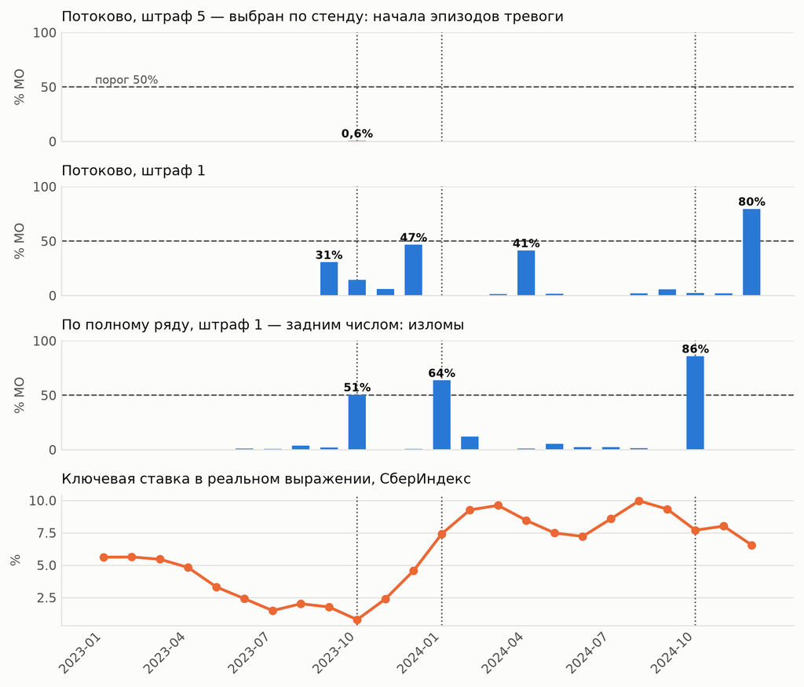

Доля муниципалитетов по месяцам: начала эпизодов тревоги в реальном времени и изломы, найденные по полному ряду задним числом; внизу — реальная ключевая ставка. Все доли — на одной шкале; штриховая линия — порог события, пунктирные вертикали — месяцы событий из конфига стенда.

События в реальном времени: порог и ранговый вид. Окно события — от его месяца до следующего события, у последнего — до конца панели. Перейдён — первый месяц окна с долей не ниже порога, звёздочка — переход в декабре позже месяца события: там порог может переводить сам декабрьский скачок; задержка — месяцы от события до перехода; наибольшая доля — за один месяц окна; в окне — доля муниципалитетов, у которых эпизод тревоги начался где-либо в окне. Ранговый вид — описание, а не второй порог: доля месяца события, её место среди наблюдаемых месяцев того же штрафа (1 — наибольшая доля, при ничьей — средний ранг) и отношение к фону — медиане долей месяцев без событий; при нулевом фоне и фоне в один-два МО отношения нет: оно было бы неустойчивым.

|  | событие | порог 50% перейдён | порог 50% задержка, мес. | порог 50% наибольшая за месяц, % | порог 50% в окне, % МО | ранговый вид в месяц события, % | ранговый вид место из 16 | ранговый вид к фону |
| --- | --- | --- | --- | --- | --- | --- | --- | --- |
| штраф 5, выбран по стенду | октябрь 2023 | нет | — | 0,6 (октябрь 2023) | 0,7 | 0,6 | 1 | — |
|  | январь 2024 | нет | — | 0,0 | 0,0 | 0,0 | 10,5 | — |
|  | октябрь 2024 | нет | — | 0,1 (декабрь 2024) | 0,1 | 0,0 | 10,5 | — |
| штраф 1 | октябрь 2023 | нет | — | 46,7 (декабрь 2023) | 67,3 | 14,4 | 5 | 6,8 |
|  | январь 2024 | нет | — | 41,4 (апрель 2024) | 47,4 | 0,2 | 14 | 0,1 |
|  | октябрь 2024 | декабрь 2024* | 2 | 79,5 (декабрь 2024) | 84,1 | 2,4 | 8 | 1,1 |

**При штрафе 5, выбранном по стенду,** доля территорий с сигналом не доходит до порога 50% ни в один месяц: наибольшая — 0,6%, в октябре 2023. За всё окно события эпизод тревоги начинается у 0,7% (октябрь 2023), 0% (январь 2024) и 0,1% (октябрь 2024) территорий. Детектор при этом штрафе на панели почти молчит: за 16 наблюдаемых месяцев эпизод тревоги начинается 16 раз на 2 028 рядов.

**Ранговый вид при штрафе 5.** По доле начал эпизодов среди 16 наблюдаемых месяцев октябрь 2023 — место 1 (0,6%, 12 МО из 2 028); январь 2024 и октябрь 2024 — место 10,5 (0%, такая же доля ещё у 10 месяцев; выше — октябрь 2023 с 12 МО, декабрь 2024 с 2 МО, ноябрь 2023 с 1 МО и декабрь 2023 с 1 МО). Наибольшая доля окна стоит выше самого месяца события: у октября 2024 — 0,1% в декабре 2024 (место 2, 2 МО). Фон — медиана долей 13 месяцев без событий, декабри в нём, — нулевой, и отношения к нему нет.

**При штрафе 1** порог 50% переходит только октябрь 2024 — в декабре 2024, с задержкой 2 месяца, а октябрь 2023 и январь 2024 — нет: наибольшие доли за месяц — 46,7 и 41,4%. Октябрь 2024 доходит до 84,1% за всё окно. У октября 2024 порог перейдён в самом декабре: 79,5% против 2,4 и 2,1% в октябре и ноябре, а декабрь 2023 при том же штрафе дал 46,7%, — это скорее декабрьский скачок, чем само событие. Октябрь 2023 до порога не доходит. В первый проверяемый месяц, сентябрь 2023, у детектора всего восемь точек темпа роста, и тревогу поднимают сразу 30,6% территорий; их эпизоды ещё идут, когда приходит октябрь 2023, и нового сигнала эти ряды не дают. За всё окно эпизод начинают 67,3% территорий, но за один месяц — не больше 46,7%, и эта наибольшая доля приходится на сам декабрь 2023 — месяц декабрьского скачка. Вместе с рядами, поднявшими тревогу на старте, это больше порога (30,6 + 46,7%) — но перешёл бы октябрь 2023 порог без старта протокола или нет, эти числа не показывают. Старт — свойство протокола, а не находка. Январь 2024 тоже не доходит — наибольшая доля в его окне 41,4%, в апреле 2024: событие, пришедшее, пока ряд ещё в тревоге, нового эпизода не начинает, а в декабре 2023 эпизод начали 46,7% территорий. Это ограничение правила эпизодов: без него один сдвиг сигналил бы дважды.

**Ранговый вид при штрафе 1.** По доле начал эпизодов среди 16 наблюдаемых месяцев октябрь 2023 — место 5 (14,4%, 293 МО из 2 028; выше — декабрь 2024, декабрь 2023, апрель 2024 и сентябрь 2023); январь 2024 — место 14 (0,2%, 4 МО из 2 028); октябрь 2024 — место 8 (2,4%, 49 МО из 2 028). Сентябрь 2023 стоит выше всех месяцев событий из-за эффекта старта: это первый проверяемый месяц, первая оценка идёт на восьми точках темпа роста, и эпизод в нём начинают все ряды, чей излом попал в первое окно. Наибольшая доля окна стоит выше самого месяца события: у октября 2023 — 46,7% в декабре 2023 (место 2); у января 2024 — 41,4% в апреле 2024 (место 3); у октября 2024 — 79,5% в декабре 2024 (место 1); из этих месяцев два — декабри. Фон — медиана долей 13 месяцев без событий, декабри в нём, — 2,1%, 43 МО; отношение доли месяца события к фону — у октября 2023 6,8, у января 2024 0,1, у октября 2024 1,1.

**Задним числом, по полному ряду при штрафе 1,** — прежняя картина: октябрь 2023 — 50,5%, январь 2024 — 63,7%, октябрь 2024 — 85,8%, в остальные месяцы не больше 12,1%; при штрафе 5 и по полному ряду излом в любой месяц находится не больше чем у 0,1% территорий. Но октябрь 2023 и январь 2024 здесь — два конца одного отрезка, а не два шока: у 1 024 из 1 025 рядов с изломом в октябре 2023 есть излом и в январе 2024, ровно через 3 месяца. Между ними — октябрь–декабрь 2023 с декабрьским скачком: средний месячный рост у этих рядов там +8,5% против +1,2% до отрезка и +1,6% после (медианы по рядам).

Картины различаются не детектором, а тем, что он видит. По полному ряду излом датируется, когда известно и то, что было после него; в реальном времени — только когда после него накопится достаточно точек, а сдвиг, пришедший, пока ряд ещё в тревоге, нового сигнала не даёт.

Доля муниципалитетов по месяцам, %: начала эпизодов тревоги в реальном времени и изломы по полному ряду задним числом — с первого месяца, где потоковый сигнал возможен; раньше детектору не хватает истории.

| месяц | потоково, штраф 5 | потоково, штраф 1 | по полному ряду, штраф 1 |
| --- | --- | --- | --- |
| сентябрь 2023 | 0,0 | 30,6 | 2,0 |
| октябрь 2023 | 0,6 | 14,4 | 50,5 |
| ноябрь 2023 | 0,0 | 6,1 | 0,4 |
| декабрь 2023 | 0,0 | 46,7 | 0,7 |
| январь 2024 | 0,0 | 0,2 | 63,7 |
| февраль 2024 | 0,0 | 0,0 | 12,1 |
| март 2024 | 0,0 | 1,3 | 0,0 |
| апрель 2024 | 0,0 | 41,4 | 0,9 |
| май 2024 | 0,0 | 1,8 | 5,5 |
| июнь 2024 | 0,0 | 0,2 | 2,5 |
| июль 2024 | 0,0 | 0,0 | 2,4 |
| август 2024 | 0,0 | 1,9 | 1,3 |
| сентябрь 2024 | 0,0 | 5,8 | 0,2 |
| октябрь 2024 | 0,0 | 2,4 | 85,8 |
| ноябрь 2024 | 0,0 | 2,1 | 0,0 |
| декабрь 2024 | 0,1 | 79,5 | 0,0 |

**Сверка с денежной политикой.** Мы сопоставили месяцы массового согласия по полному ряду с реальной ключевой ставкой из датасета СберИндекса — то есть тем же источником, что исключает расхождение методологий.

Месяцы массового согласия по полному ряду и реальная ключевая ставка СберИндекса. Ранг — место модуля изменения ставки к прошлому месяцу среди всех изменений периода; первое — самое сильное.

| месяц | согласие МО по полному ряду, штраф 1, % | реальная ставка, % | изменение к прошлому месяцу, п. п. | ранг изменения из 23 |
| --- | --- | --- | --- | --- |
| октябрь 2023 | 50,5 | 0,79 — минимум периода | −0,98 | 11 |
| январь 2024 | 63,7 | 7,42 | +2,85 | 1 |
| октябрь 2024 | 85,8 | 7,70 | −1,63 | 4 |

Октябрь 2023 — минимум реальной ставки за период (0,79; по величине изменения лишь 11-й месяц из 23), после которого она пошла вверх. Январь 2024 — сильнейшее изменение реальной ключевой ставки за период. Октябрь 2024 — 4-е по силе изменение ставки из 23.

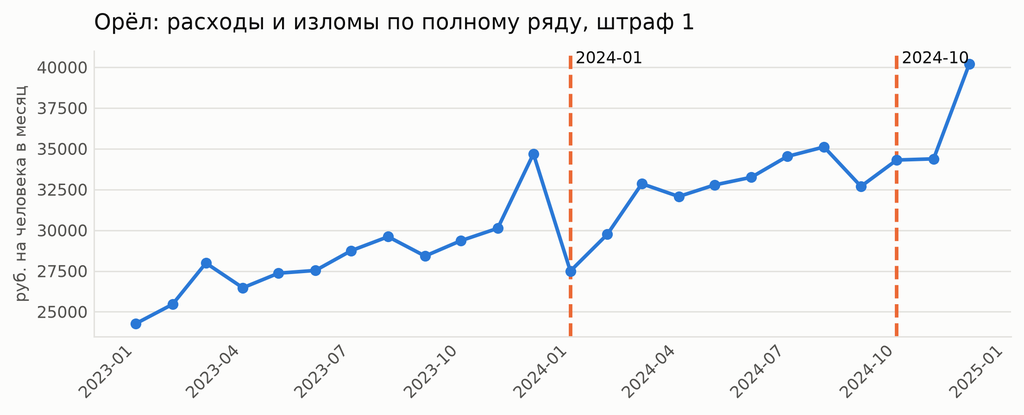

Офлайновый разбор одного ряда: изломы, найденные по полному ряду, отмечены пунктиром. Сигнал системы — не изломы отдельного ряда, а доля территорий, у которых в этом месяце началась тревога (выше).

**Ограничения, без которых этот результат нельзя читать.**

Трёх событий недостаточно для вывода о причинности. Связь с разворотами денежной политики — совпадение и гипотеза, не больше: на трёх точках ничего не доказывается, а в реальном времени при штрафе 5, выбранном по стенду, ни одно из событий не доходит до порога 50%: наибольшая доля за месяц — 0,6%, за всё окно события — 0,7%.

Январь неотделим от сезонности. Ряд начинается в январе 2023, и изменение в первом январе обнаружить физически нельзя — детектируемый январь у нас ровно один. Различить «январский провал спроса» и «шок ставки» на двухлетней истории невозможно. Октябрь 2024 — такой же случай: отрезок от излома до конца панели — 3 месяца, октябрь–декабрь 2024, и в него попадает декабрьский скачок — +17,9% у медианного из 1 741 ряда с этим изломом. Шок и декабрьскую сезонность здесь тоже не разделить.

## Фундаментальные модели временных рядов

Chronos-Bolt подключён в трёх размерах и работает без дообучения. Логика применения такая: классические модели упёрлись в нехватку данных для оценки параметров, а фундаментальная модель параметры не оценивает — она переносит статистику, выученную на миллионах чужих рядов.

**Из коробки она проигрывает наивной модели.** Диагноз виден на одном ряду: при обучающей истории, растущей с 24 до 33 тысяч рублей, Chronos предсказывает плавное снижение. Модель инвариантна к масштабу и не воспроизводит инфляционный рост в 15–17 процентов годовых.

Гипотеза, что логарифмирование превратит мультипликативный тренд в аддитивный и это поможет, **не подтвердилась**: на полной панели логарифм у `small` снижает MAE на 0,8% (2 620 → 2 598); у `base` снижает MAE на 0,5% (2 462 → 2 451) — меньше процента у обоих размеров.

**Ансамбль: как мы поймали себя на подгонке.** Это опыт стадии отбора, на подвыборке из 300 рядов; на полной панели ансамбль не перегонялся. Смесь глобальной и фундаментальной модели с весом 0,7 дала MAE 1 349 против 1 492 у глобальной одной — улучшение на 9,6 процента, и корреляция ошибок двух моделей 0,47 давала этому правдоподобное объяснение: модели ошибаются в разных местах.

Вес 0,7 был подобран по тем же данным, на которых считалась метрика. При честном подборе — вес оценивается на первом фолде и применяется к остальным — картина перевернулась: 1 456 против 1 040, ансамбль **хуже** на сорок процентов. Оптимальный вес нестабилен между фолдами, и подгонка создавала иллюзию улучшения.

### Дообучение: главное, что меняет вывод

Отрицательный результат по zero-shot был бы преждевременным без очевидного следующего шага. Chronos-Bolt дообучен на нашей панели — одна модель на фолд, а не своя на каждый из 2028 рядов: две тысячи дообучений на пятнадцати точках каждое были бы не дообучением, а переобучением.

**Валидация оказалась важнее скорости обучения.** Сначала ранняя остановка делалась по отложенным рядам: муниципалитетов две тысячи, десятой части не жалко, а каждый из пятнадцати месяцев на счету. Потеря на отложенных рядах уверенно падала — а MAE на тестовых месяцах росла. Причина в том, что сдвиг здесь во времени, а не в сечении: отложенные ряды живут в тех же месяцах, что и обучающие, и увидеть, что модель заучивает декабрьско-январские переходы и потащит их в апрель, они не могут в принципе. После переноса валидации на последние месяцы обучающей части дообучение стало улучшать прогноз zero-shot на всех фолдах.

**Воспроизводимость: реализации до и после исправлений.** Повторное дообучение на тех же трёх фолдах — в прогоне по горизонтам, тем же кодом и на тех же данных — дало другое число. Главная причина, по-видимому, — сид задавался только выборке батчей, а dropout внутри модели в режиме обучения брал глобальный генератор torch, который не сидировался. При разборе нашлась и вторая ошибка, методическая: проверочные окна — последние h origin каждого ряда — заходили целями в цели обучающих окон на h − 1 месяцев, и ранняя остановка отчасти судила по месяцам, которые модель уже учила. Теперь генератор сидируется, проверочное окно — последний origin ряда, а цели обучающих окон кончаются раньше первого проверочного месяца. В таблице — пять реализаций: текущие строки и три снимка прежних прогонов из `results/realizations/`. Снимки взяты из локального прогона и в репозиторий не входят: на чистом клоне здесь останутся только текущие реализации.

Реализации дообученного Chronos-Bolt small на трёх фолдах горизонта 3, MAE, ₽. Валидация «с пересечением» — проверочные окна заходили целями в обучающие, «без пересечения» — после исправления 26.09; сид — сидирован ли генератор torch при дообучении. Реализации до и после исправления — оценки разных процедур и в одно среднее не сводятся. Строки, кроме текущих, — снимки results/realizations/ локального прогона; в репозиторий они не входят.

|  | валидация | сид | фолд 0 | фолд 1 | фолд 2 | среднее |
| --- | --- | --- | --- | --- | --- | --- |
| основной прогон до исправления | с пересечением | нет | 2 026 | 1 203 | 1 587 | 1 606 |
| прогон горизонтов до исправления, h = 3 | с пересечением | нет | 2 043 | 1 131 | 2 142 | 1 772 |
| основной прогон, первый с сидом | без пересечения | да | 2 001 | 1 152 | 2 326 | 1 826 |
| основной прогон, повтор с тем же сидом | без пересечения | да | 2 001 | 1 152 | 2 337 | 1 830 |
| прогон горизонтов, h = 3, с сидом | без пересечения | да | 2 001 | 1 152 | 2 352 | 1 835 |

**Главная оговорка — третий фолд.** До исправления две реализации одной процедуры давали на нём 1 587 и 2 142, в среднем по фолдам — 1 606 и 1 772 (снимки локального прогона, в репозиторий не входят). После исправления три прогона с сидом совпали на первом и втором фолдах до копейки на ряд — до последнего знака лишь 48–74% рядов, у остальных расхождение не больше 0,006 ₽ — и разошлись на третьем: от 2 326 до 2 352, на отдельном ряду до 158 ₽. Детерминизм, стало быть, подтверждён не целиком: по-видимому, сид воспроизводит выборку батчей и dropout, но не все вычисления на MPS. Один из этих прогонов — снимок локального прогона, в репозиторий не входит. Реализации до и после исправления — оценки разных процедур, и в одно среднее мы их не сводим. В сводной таблице стоит последняя реализация основного прогона, 1 830; прогоны с сидом дают от 1 826 до 1 835, в диапазоне — снимок локального прогона, в репозиторий не входит.

### Второе и третье семейства

По одному семейству нельзя отличить «фундаментальные модели не годятся для таких рядов» от «не годится именно Chronos». Взяты ещё два, и архитектуры у всех трёх разные: Chronos-Bolt — энкодер-декодер на патчах поверх T5, TimesFM 2.5 — декодер на патчах с квантильным выходом, Moirai 1.1-R — маскированный энкодер с вероятностным выходом в виде выборки.

Дообучения у этих двух нет, хотя оно возможно: у Moirai в библиотеке uni2ts есть `MoiraiFinetune`, в репозитории TimesFM 2.5 — пример дообучения LoRA. Мы не дообучали ни ту, ни другую — не хватило бюджета времени, — поэтому вывод о дообучении ниже относится к Chronos, а не к фундаментальным моделям вообще.

У Moirai размер патча выбирается по **отложенным месяцам обучающей части** — origin сдвигается на горизонт назад, кандидаты сравниваются на месяцах, которых модель при этом не видит. Выбор оказался не формальностью: на первом фолде по отложенным месяцам выигрывает патч 16, на втором и третьем — патч 8 (по журналу прогона), и по тесту его подбирать было бы нельзя.

Выборка Moirai теперь сидирована: основной прогон и прогон горизонтов на горизонте 3 дали одинаковые до последнего знака ошибки на всех 6 084 парах ряд × фолд. Прежний, несидированный прогон давал 2 265 против нынешних 2 268 (снимок локального прогона, в репозиторий не входит).

|  | фолд 0 | фолд 1 | фолд 2 | MAE | к наивной, % |
| --- | --- | --- | --- | --- | --- |
| Chronos-Bolt small, zero-shot | 2 155 | 1 789 | 3 915 | 2 620 | −41,4 |
| Chronos-Bolt base, zero-shot | 2 385 | 1 624 | 3 379 | 2 462 | −32,9 |
| Moirai 1.1-R small, zero-shot | 2 720 | 1 258 | 2 827 | 2 268 | −22,5 |
| TimesFM 2.5 200M, zero-shot | 2 434 | 1 325 | 2 600 | 2 120 | −14,4 |
| Chronos-Bolt base, дообученный | 2 358 | 1 706 | 1 947 | 2 004 | −8,2 |
| Chronos-Bolt small, дообученный | 2 001 | 1 152 | 2 337 | 1 830 | +1,2 |
| наивная модель | 805 | 1 218 | 3 535 | 1 852 | 0,0 |
| эталон конкурса | 1 096 | 1 442 | 2 205 | 1 581 | +14,7 |

Три семейства и три подхода вместо одного, и все дают согласованный вывод.

**Zero-shot проигрывает наивной модели во всех трёх семействах.** Chronos small хуже её на 41%, Moirai на 22%, TimesFM на 14%. Это средние по трём фолдам: на третьем фолде наивную обходят Moirai, TimesFM и Chronos base — 2 827, 2 600 и 3 379 против 3 535. На горизонтах 1 и 3 в среднем проигрывают все три; на длинных наивная модель сама слабеет, и её обходят: на горизонте 6 — TimesFM (2 430 против 2 632), но не эталон (2 137), и то лишь в среднем: при обучении 18 мес. он хуже наивной — 2 321 против 2 011; на горизонте 12 — Moirai (2 580 против 2 691), причём обходит и эталон (2 722). Горизонт 12 — один фолд, и это одно число без интервала.

Три независимые архитектуры на основном горизонте в среднем сходятся, значит дело не в конкретной модели, а в самой задаче: фундаментальная модель инвариантна к масштабу и переносит статистику чужих рядов, а здесь решает общероссийское движение конкретных девяти месяцев, которого в чужих рядах нет.

**Дообучение Chronos отыгрывает 30% ошибки, но только до уровня наивной модели — и только на основном горизонте.** Chronos-Bolt small: 2 620 без дообучения, 1 830 после. Модель перестаёт проигрывать наивной: в среднем обходит её на 1,2%, пофолдово — на 2 фолдах из 3; первый фолд проигрывает, как и все панельные модели. До эталона конкурса она не доходит: 1 830 против 1 581. Панельной модели она уступает в 1,5 раза: 1 830 против 1 217.

**Больше параметров — в среднем хуже.** Дообученный `base` (205 млн параметров) даёт 2 004 против 1 830 у `small` (48 млн); по фолдам `base` хуже на первом и втором фолдах — 2 358 против 2 001, 1 706 против 1 152, — и лучше на третьем: 1 947 против 2 337 — разрыв 390 ₽ больше разброса реализаций `small` с сидом на этом фолде (26 ₽), так что повтором его не объяснить; разброс самого `base` по одной реализации с сидом не оценить. При двенадцати тысячах обучающих примеров первого фолда (по журналу прогона) лишняя ёмкость скорее мешает, чем помогает.

Рубрика конкурса требует продемонстрировать «преимущества и ограничения» фундаментальных моделей. И то, и другое здесь количественно. Преимущество — дообучение снимает 30% ошибки zero-shot на основном горизонте. Ограничения — отставание от панельной модели в 1,5 раза; на наукасте дообучение снимает лишь 1,6% ошибки zero-shot (2 026 → 1 994) и остаётся на 23,8% хуже наивной, а на фолдах с обучением 15 и 20 мес. хуже самого zero-shot; на горизонтах 6 и 12 дообученной модели нет ни на одном фолде — при обучении 12 и 18 мес. дообучение пропускается или отказывает; наконец, разброс реализаций на третьем фолде: до исправления — 1 587–2 142, после — 2 326–2 352 (часть чисел — снимки локального прогона, в репозиторий не входят).

## Интеграция новостных данных

### Источник

Готовых корпусов с нужным сочетанием свойств не нашлось. GDELT покрывает период и имеет чистую лицензию, но по России даёт около трёх процентов событий, из которых три четверти городских приходятся на Москву, а русскоязычных первоисточников в проверенной выборке не оказалось вовсе.

Работающий путь — **датированные архивы региональных изданий**. Регион определяется доменом издания по построению, без геокодирования и без догадок.

Собрано 588 586 заголовков по 18 регионам за 24 месяца. Соблюдены `robots.txt` каждого сайта, пауза между запросами и честный User-Agent с контактом. Четыре издания исключены сознательно: одно отдавало отказ нашему агенту, одно прямо запрещало массовый сбор в `robots.txt`, два не позволяли подтвердить дату публикации.

Из 18 регионов корпуса в матрице моделирования представлены 14: 396 рядов из 2 028 (19,5%), это 1 188 пар ряд × фолд основного протокола. По регионам: Московская область — 51, Республика Татарстан — 42, Пермский край — 41, Новосибирская область — 33, Челябинская область — 32, Самарская область — 31, Кемеровская область — 28, Волгоградская область — 27, Тюменская область — 24, Архангельская область — 21, Орловская область — 21, Ульяновская область — 18, Амурская область — 16, Мурманская область — 11. Ещё четыре региона корпуса — Воронежская область, Краснодарский край, Курская область и Ростовская область — в выгрузке почти не представлены: из 33–55 муниципалитетов каждого по справочнику в панели встречаются 2–7 названий, и все они — омонимы, которым регион не приписывается. Региональные конструкции видят только эти 396 рядов; национальная работает с федеральным агрегатом целиком.

### Признаки

Интенсивность считается как отклонение от собственного среднего издания, а не как число публикаций: одно издание дало треть корпуса, и в абсолютных величинах его регион перевесил бы все остальные. Доли тематических упоминаний считаются от числа публикаций месяца и от активности редакции не зависят.

### Чистка словаря тем

Темы ищутся по корням в транслитерированном заголовке. До 25 сентября корень засчитывался в любом месте слова, и в темы набился мусор: корень ставки `stavk` находил «выставку», «отставку», «поставку» и «доставку», корень цены `cen` — «центр». Теперь корень должен начинать слово; исключение — корни, законно живущие внутри сложных слов, вроде нефтезавода, Сбербанка и госдолга. Что сняла чистка (`scripts/build_news_features.py`):

Словарь тем до и после чистки: заголовки корпуса, попавшие в тему; «снято» — доля прежних попаданий, которые новый словарь больше не засчитывает; частые снятые слова — в транслитерации, с числом заголовков; корреляция — помесячных долей темы по стране, старый словарь против нового.

|  | заголовков до | после | снято, % | частые снятые слова | корреляция рядов |
| --- | --- | --- | --- | --- | --- |
| цены | 28 412 | 11 358 | 60,0 | czentre 3988; czentr 1221; tsentre 974; tsentr 874; tsentra 683 | 0,929 |
| доходы | 11 361 | 11 121 | 2,1 | ledohod 52; kompensirovat 37; kompensirujut 25; kompensiruyut 17; kompensiruet 13 | 0,993 |
| занятость | 22 124 | 17 839 | 19,4 | zarabotal 342; zarabotat 331; zarabotala 243; razrabotali 229; zarabotali 205 | 0,886 |
| производство | 7 559 | 7 555 | 0,1 | vaicekhovskogo 3; khimcekha 1 | 1,000 |
| кредит | 18 218 | 11 317 | 37,9 | vystavka 1069; vystavke 592; vystavku 479; otstavku 344; postavki 289 | 0,871 |
| торговля | 18 510 | 18 385 | 0,7 | nezakrytye 13; narkotorgovecz 12; narkotorgovki 12; kriptotorgovczev 11; narkotorgovczev 10 | 0,999 |
| денежно-кредитная политика | 6 662 | 2 580 | 61,3 | vystavka 1069; vystavke 592; vystavku 479; otstavku 344; postavki 289 | 0,768 |

Чистка сняла 61,3% попаданий темы денежно-кредитной политики и 60,0% — темы цен, в остальных темах — от 0,1% до 37,9%; частые снятые слова в таблице показывают, что снят в основном мусор. У кредита и денежно-кредитной политики списки снятых слов одинаковы: корень ставки `stavk` стоит в обеих темах, и «выставка» с «отставкой» уходили из обеих. Новый словарь только снимает: добавленных попаданий нет ни в одной теме.

**Прежние числа новостной модели `two_stage_news` и новостных проверок ниже считались на грязном словаре.** Всё, что приведено дальше, — второй прогон, на очищенном словаре; прежнее число названо там, где чистка перевернула вывод. Признаки в глобальной модели и корреляция с изломами в первый раз считались вручную, без скрипта; теперь их считает `scripts/news_panel.py`, и числа ниже — его.

### Признаки в модели: панельная модель с новостями и без

`global_gbm_news` — та же панельная модель, что `global_gbm`, плюс новостные признаки ряда: шесть долей тем его региона за месяц origin. Доля темы месяца считается только по публикациям этого месяца; интенсивность публикаций в признаки не входит — она нормирована средним издания за весь период и заглядывала бы вперёд. У рядов регионов без изданий признаков нет: пропуск, а не ноль. Сравнение — по парам ряд × фолд, на рядах, покрытых новостями, и на всех; `scripts/news_panel.py` → `results/news_panel.csv`.

Панельная модель с новостными признаками против той же модели без них. Разница — с новостями минус без, в рублях: минус — новости помогают. Интервал по парам считает пары ряд × фолд независимыми; интервал по фолдам — по t с числом фолдов минус один степенями свободы: пары одного фолда делят одни и те же месяцы. Покрытые — ряды регионов, которые есть в корпусе.

|  | ряды | рядов | MAE без новостей | с новостями | разница | по парам | по фолдам | рядов лучше | фолдов лучше |
| --- | --- | --- | --- | --- | --- | --- | --- | --- | --- |
| наукаст, h = 1 | покрытые новостями | 396 | 869 | 848 | −21,5 | [−28,6; −14,4] | [−77,9; +34,9] | 59% | 5 из 9 |
|  | все | 2 028 | 969 | 971 | +2,8 | [+0,5; +5,0] | [−35,4; +41,0] | 47% | 5 из 9 |
| h = 3 | покрытые новостями | 396 | 1 318 | 1 293 | −24,3 | [−34,7; −13,9] | [−254,1; +205,5] | 58% | 2 из 3 |
|  | все | 2 028 | 1 466 | 1 490 | +24,2 | [+20,8; +27,6] | [−177,5; +225,8] | 30% | 2 из 3 |

**Самая мощная проверка — наукаст, девять фолдов.** На 396 рядах, покрытых новостями, модель с новостями точнее на 21,5 ₽ (2,5% MAE), и интервал по парам [−28,6; −14,4] ноль не накрывает; но интервал по фолдам [−77,9; +34,9] ноль накрывает: модель с новостями лучше на 5 фолдах из 9, у 59% рядов. На основном протоколе — точнее на 24,3 ₽, по фолдам [−254,1; +205,5], лучше на 2 фолдах из 3. **По правилу, записанному до прогона, выигрыш не установлен: и самая мощная проверка — ноль.** На всех 2 028 рядах модель с новостями не лучше базовой: +2,8 ₽ на наукасте и +24,2 ₽ на горизонте 3. У 1 632 рядов без новостей признаки пусты, но модель обучена уже другой, и их ошибка в среднем выше — на 8,7 ₽ на наукасте и 35,9 ₽ на горизонте 3 (по парам; по фолдам, как и выигрыш покрытых рядов, не установлено), — и в сумме по панели выигрыша нет.

**Чем ограничена конструкция.** Новости привязаны к региону, а прогнозируем мы муниципалитеты: от 11 до 51 ряда одного региона получают один и тот же признак. И экономические темы — малая доля потока: в среднем от 1,1 до 3,1% заголовков месяца на тему.

### Корреляция с изломами — та же региональная проверка другим тестом

Вторая гипотеза — новостной сигнал совпадает не с уровнем потребления, а с изломами — в первом прогоне проверялась корреляцией по всем точкам регион × месяц сразу. Такая корреляция мерит общий календарь: изломы в разборе по полному ряду сидят в трёх общих месяцах, и точки одного месяца не независимы. Если же снять месяц и сравнивать регионы внутри него, получается ровно региональная, главная часть событийной проверки ниже, только корреляционным тестом вместо перестановочного. Поэтому отдельной конструкцией она не считается; `scripts/news_panel.py` считает её для сверки.

Внутри месяца — 252 точки регион × месяц, шесть тем в тот же месяц и в предыдущий, порог Бонферрони |t| > 2,89 (|r| > 0,19), объявленный до прогона: **не прошла ни одна из 12 проверок**; ближе всех кредит в тот же месяц, r = +0,124, p = 0,059. В пуле, как в первом прогоне, порог прошли бы цены в тот же месяц, доходы в тот же месяц и торговля месяцем раньше (r = +0,22, +0,18 и +0,21), но пул считает 252 точки независимыми, а по сути это 18 месяцев с общими для регионов изломами и новостным фоном: внутри месяца от этих связей остаётся r = +0,05, +0,08 и +0,02.

### Событийная проверка: прямо на найденных изломах

Первая конструкция искала связь вслепую — подавала признаки в модель и смотрела на метрику. Вторая проверка прямая. Разбор по полному ряду нашёл три месяца массового согласия: октябрь 2023 (50,5% муниципалитетов), январь 2024 (63,7%), октябрь 2024 (85,8%); в остальные месяцы не выше 12,1%. Это изломы задним числом, при штрафе 1: `scripts/news_event_study.py` берёт именно их (`PENALTY = 1.0`), а не потоковый сигнал. Вопрос простой: отличается ли новостной фон в эти три месяца от прочих.

Проверок две, потому что они отвечают на разное.

**Общероссийская** — три месяца против двадцати одного по среднему по регионам. Значимость считается точным перестановочным тестом: троек из 24 месяцев ровно 2024 штуки, их можно перебрать все и получить точное p-значение вместо теории, которая на трёх наблюдениях не работает.

**Региональная, главная** — по панели регион × месяц с поправкой на месяц. Общероссийская проверка не отличает «новости предсказывают излом» от «в этот месяц и новостей много, и изломов много, потому что это декабрь». Поэтому и признак, и отклик центрируются по месяцу, и сравниваются регионы **внутри одного месяца**: если в регионе новостной фон необычен для этого месяца, чаще ли там ломаются ряды, чем у соседей в тот же месяц.

Семь признаков на трёх сдвигах — двадцать одна гипотеза, порог Бонферрони 0,0024 объявлен до расчёта.

|  | признак | сдвиг | p (перестановки) | наклон | прошёл порог 0,0024 |
| --- | --- | --- | --- | --- | --- |
| 15 | t_kredit | 0 | 0,08 | 1,23 | нет |
| 2 | intensity | 2 | 0,20 | −0,01 | нет |
| 1 | intensity | 1 | 0,21 | 0,01 | нет |
| 4 | t_ceny | 1 | 0,26 | 0,58 | нет |
| 6 | t_dohody | 0 | 0,33 | 0,65 | нет |
| 5 | t_ceny | 2 | 0,41 | 0,49 | нет |

**Ни одна из 42 проверок ничего не нашла**: в файл результатов записана региональная часть, 21 проверка, а общероссийскую, из стольких же проверок, скрипт только печатает. И это результат сильнее предыдущего: лучшее p-значение в региональной, главной проверке — 0,078 у темы кредита со сдвигом 0, то есть ни один признак не значим даже **без** поправки на множественность; общероссийская проверка тоже не дала ни одного p ниже 0,05 (по журналу скрипта). Раньше у нас был один кандидат, не переживший Бонферрони, — теперь кандидатов нет вовсе.

Обе региональные конструкции — признаки в модели и событийный анализ на найденных изломах (корреляция внутри месяца отвечает на тот же вопрос и даёт тот же ответ) — своих порогов не проходят. Это уже не «попробовали и бросили».

### Третья конструкция: не то разрешение

Две предыдущие конструкции искали **региональный** новостной сигнал против **муниципальных** рядов. Разложение ошибки объяснило, почему они не могли ничего найти: межрядовая составляющая не двигается ни одной из шести моделей, для которых посчитано разложение, а всё, что двигается, — это общероссийское движение. Мы искали сигнал там, где изменчивости почти нет.

Поэтому корпус свёрнут в один национальный ряд и проверен против того самого федерального агрегата, который прогнозирует первый этап двухэтапной модели. Добавлена отдельная тема денежно-кредитной политики — ставка, ЦБ, инфляция, регулятор: три месяца массового согласия, найденные задним числом по полному ряду, пришлись на разворот и крупные изменения реальной ставки — гипотеза, которую стоило проверить: если новости реагируют хоть на что-то, то на это.

Восемь признаков, две проверки — объясняют ли новости остаток прогноза агрегата и отличается ли фон в месяцы изломов, — три горизонта и три сдвига. **Сорок восемь гипотез, порог Бонферрони 0,00104, объявлен до расчёта.**

|  | проверка | признак | сдвиг | наклон | p | прошёл порог 0,00104 |
| --- | --- | --- | --- | --- | --- | --- |
| 0 | остаток агрегата | intensity | 3 | −0,0241 | 0,0012 | нет |
| 1 | события | t_torgovlja | 1 | +0,0051 | 0,0311 | нет |
| 2 | остаток агрегата | t_dkp | 3 | −5,8768 | 0,0350 | нет |
| 3 | остаток агрегата | t_dohody | 2 | −4,2232 | 0,0456 | нет |
| 4 | остаток агрегата | t_ceny | 3 | −2,5518 | 0,0720 | нет |
| 5 | остаток агрегата | t_dohody | 1 | −2,8559 | 0,0810 | нет |
| 6 | остаток агрегата | intensity | 2 | −0,0129 | 0,0828 | нет |
| 7 | остаток агрегата | t_ceny | 2 | −1,8678 | 0,1450 | нет |

**Не прошла ни одна.** Лучшее p — 0,0012 у интенсивности публикаций на горизонте 3 мес., и это при пороге 0,00104. На уровне 0,05 без всякой поправки значимы четыре гипотезы из 48 — при 2,4, которые в среднем даёт одна случайность на таком числе проверок.

Отдельная оговорка про интенсивность, у которой p оказалось наименьшим: за два года корпус вырос с 19,7 до 30 тысяч публикаций в месяц, и «интенсивность» на таком ряде — это в основном тренд. Тренд коррелирует с чем угодно, что тоже растёт или падает, и принимать это за новостной сигнал было бы наивно.

### Конструктивная проверка тоже ничего не дала

Тезис проверен не только гипотезами, но и моделью: `two_stage_news` правит прогноз агрегата новостями, причём признак выбирается перекрёстной проверкой с выбрасыванием по одному и только на месяцах до origin.

|  | фолд 0 | фолд 1 | фолд 2 | среднее |
| --- | --- | --- | --- | --- |
| без новостей | 781,24 | 1 586,64 | 1 810,54 | 1 392,81 |
| с новостной поправкой | 1 113,53 | 1 721,75 | 1 665,79 | 1 500,36 |
| разница | 332,28 | 135,11 | −144,74 | 107,55 |

На очищенном словаре новости прогнозу вредят: 1 500 против 1 393 без них, на 108 ₽ хуже в среднем. Пофолдово поправка вредит на первом и втором фолдах (+332 ₽ и +135 ₽) и выигрывает на третьем (−145 ₽) — одна удачная попытка из трёх. На словаре до чистки та же модель давала 1 313 (снимок локального прогона, в репозиторий не входит) — выигрыш в 80 ₽, который после чистки словаря исчез. На горизонтах поправка тоже хуже двухэтапной модели без неё — на каждом: h = 1 — 1 070 против 1 018; h = 3 — 1 500 против 1 393; h = 6 — 1 985 против 1 749; h = 12 — 1 878 против 1 642.

Отбор признака на очищенном словаре стал устойчивее: на первом шаге все три фолда основного протокола берут тему доходов, на третьем — тему денежно-кредитной политики, ту самую, которую мы и ждали (по журналу прогона). Прогноз от этого лучше не стал, а выигрыш на одном фолде из трёх сигналом не назовёшь.

### Сколько теряется на заголовках

Остаётся возражение: весь корпус — это заголовки, а тема в заголовке может не называться. Статья про решение по ставке вполне называется «Что будет с ипотекой». Проверено выборкой в двадцать тысяч статей, у которых скачаны тела.

| тема | по заголовку, % | с телом, % | рост, раз | добрано | добрано, % от непопавших |
| --- | --- | --- | --- | --- | --- |
| ceny | 2,45 | 3,53 | 1,44 | 121 | 1,10 |
| dohody | 2,26 | 3,43 | 1,52 | 132 | 1,20 |
| zanjatost | 2,83 | 8,72 | 3,08 | 663 | 6,06 |
| proizvodstvo | 1,25 | 3,27 | 2,61 | 227 | 2,04 |
| kredit | 2,26 | 3,38 | 1,50 | 126 | 1,15 |
| torgovlja | 2,94 | 6,00 | 2,04 | 344 | 3,15 |
| dkp | 0,76 | 1,31 | 1,72 | 62 | 0,55 |

Доля попаданий в тему растёт в 1,4–3,1 раза. Но **из статей, не попавших в тему по заголовку, тело добирает медианно 1,2%** — от 0,6% до 6,1%. Заголовок, как выясняется, называет тему почти всегда, когда она вообще есть.

Главное же — связь с целевой величиной. Корреляция помесячного ряда доли с остатком прогноза агрегата меняется от добавления тела медианно на 0,088, а тот же ряд, посчитанный по выборке вместо всего корпуса, отличается от корпусного на 0,173. **Эффект тела вдвое меньше шума выборки**, то есть при этом объёме его нельзя даже измерить, а измеримая часть мала.

**Артефакт, который чуть не стал находкой.** Первый расчёт дал поразительное: все семь тем разом перевернули корреляцию с отрицательной на +0,27…+0,62, монотонно растущую с горизонтом. Семь несвязанных тем не могут вести себя одинаково — и не вели. Средняя длина тела гуляет по месяцам от 2 613 до 3 421 символа и сама коррелирует с остатком на −0,21, −0,43 и −0,54. Длиннее текст — больше шансов попасть в любую тему; находкой была длина текста. После того как тело у всех статей обрезано до одинаковых 1 500 символов, эффект исчез.

Полная выкачка всех 588 586 тел стоила бы около двенадцати часов обхода и увеличила бы корпус примерно в пятьдесят раз. **Решение: не делать.** Не потому, что дорого, а потому, что измеренный выигрыш — 1,2% добранных статей и изменение связи вдвое меньше собственного шума.

## Что означает показатель и чего мы не утверждаем

Показатель — оценка среднедушевых безналичных расходов, публикуемая СберИндексом. Методология именно муниципального показателя не опубликована: неизвестно, среднее это или медиана и делится ли сумма на всё население территории.

Это не праздный вопрос. Сопоставление с медианной зарплатой из открытых данных СберИндекса даёт отношение около 0,66 по панели: подушевые безналичные расходы составляют две трети медианной зарплаты **на одного работающего**. С учётом того, что занятых примерно половина населения, безналичные траты оказываются сопоставимы со всем денежным доходом, не оставляя места ни наличным, ни сбережениям.

Расхождение объясняется несколькими каналами, и ни один не требует предполагать ошибку в данных. Карточный оборот не равен потреблению: в нём переводы, покупки для других лиц, траты с личных карт на бизнес. Статистика оплаты труда не покрывает весь денежный доход — Росстат публикует отдельную оценку скрытой оплаты труда в системе национальных счетов. Наконец, показатель подушевой, а областной центр обслуживает жителей соседних районов, чьи траты приписываются городу, — СберИндекс измеряет этот эффект отдельным индексом мобильности.

**Практическое следствие для работы.** Мы прогнозируем опубликованный ряд, и MAE считается по нему; это утверждение от вопроса об уровне не зависит. Там, где нужна интерпретация, мы опираемся на относительные величины — темпы роста, различия между территориями, точки структурных изменений, — которые устойчивы к постоянному смещению уровня. Мы не утверждаем, что жители тратят ровно столько.

## Воспроизводимость

Отчёт и слайды собираются из закоммиченных результатов без единого прогона — что лежит в репозитории, сказано ниже. Пересчитать числа заново можно командами ниже; время — на полной панели, на машине автора (macOS arm64), по журналам прогонов и замеру на чистом клоне 28.09; у скриптов, которые мерились на чистом клоне, выход совпал с закоммиченным байт в байт.

```bash
python -m venv .venv
.venv/bin/pip install -r requirements.txt
.venv/bin/python -u scripts/check_no_leakage.py        # внешние ряды не заглядывают за origin
.venv/bin/python -u src/run.py --config configs/full.yaml  # основной протокол → results/per_series.csv, summary.csv;
                                                        #   модели гонялись по одной (--models): от минуты до 5 ч 37 мин
                                                        #   у prophet_forced_yearly (машина уходила в подкачку)
.venv/bin/python -u scripts/horizons.py                 # пять горизонтов, 2 ч 41 мин → results/horizons_*.csv
.venv/bin/python -u scripts/error_decomposition.py      # около 12 минут → results/error_decomposition.csv
.venv/bin/python -u scripts/training_length_sweep.py    # около 32 минут → results/training_length_sweep.csv
.venv/bin/python -u scripts/changepoints.py             # стенд разладок v2, около 7 минут → results/cp_*.csv
.venv/bin/python -u scripts/changepoints.py --config configs/changepoints_v1.yaml
                                                        #   первая версия стенда, около 2 минут → results/cp_v1/
.venv/bin/python -u scripts/forecast_forward.py        # прогноз на 2025 год, около 3 минут →
                                                        #   results/forecast_2025.csv, forecast_2025_aggregate_check.csv
.venv/bin/python -u scripts/build_news_features.py      # словарь тем → results/news_dictionary.csv,
                                                        #   data/news/monthly.parquet и national.parquet;
                                                        #   нужен локальный data/news/headlines.parquet (ниже)
.venv/bin/python -u scripts/news_national.py            # около 15 секунд → results/news_national.csv
.venv/bin/python -u scripts/news_event_study.py         # около 12 секунд → results/news_event_study.csv
.venv/bin/python -u scripts/news_panel.py               # около 8 секунд, новости в модели и изломы →
                                                        #   results/news_panel.csv, news_breaks_corr.csv
                                                        #   (после run.py, horizons.py и changepoints.py)
.venv/bin/python -u scripts/fetch_bodies.py             # выборка тел статей (обход сайтов, в git не входит)
.venv/bin/python -u scripts/compare_headline_body.py    # → results/headline_vs_body.csv, headline_vs_body_corr.csv
.venv/bin/python -u scripts/export_results.py           # снимки .csv.gz построчных файлов для git; --check — сверка
```

Протокол оценки целиком вынесен в `configs/full.yaml` (пилот на 300 рядах — `configs/baseline.yaml`): ни горизонта, ни правил разбиения в коде моделей нет. Смена постановки — правка одного файла, а не переписывание. Пять горизонтов заданы так же — в `configs/horizons.yaml`; `scripts/horizons.py` считает их и сохраняет ошибку по каждому шагу горизонта. Прогноз вперёд от конца панели — тоже: origin, горизонты и модель на каждом горизонте заданы в `configs/forecast_forward.yaml`, а `scripts/forecast_forward.py` пишет прогноз по муниципалитетам и проверку федерального агрегата по факту; прогнозным моделям агрегат передаётся обрезанным по origin, целиком — только разносу опубликованного агрегата. Стенд обнаружения структурных изменений — тоже: выборка, врезки, режимы подготовки, сетка штрафов, правила зачёта (граница задержки и нетронутый близнец), правило выбора штрафа для реальных данных, порог и события потокового сигнала заданы в `configs/changepoints.yaml`, а `scripts/changepoints.py` пишет по ним десять файлов `results/cp_*.csv` — первой колонкой в каждом стоит версия протокола, — из которых раздел об обнаружении берёт все числа. Первая версия стенда, о которой отдельный подраздел, воспроизводится тем же скриптом с `configs/changepoints_v1.yaml` и пишет в `results/cp_v1/`. `scripts/build_news_features.py` пересобирает признаки новостей по текущему словарю тем, и новостные скрипты после него читают уже их. `scripts/backfill_r2.py` при прогоне с нуля не нужен: это разовый бэкфилл слагаемых R² пула в результаты, посчитанные до 25.09, — нынешние прогоны пишут их сами.

Данные лежат в репозитории: панель СберИндекса, справочник муниципальных образований, длинные ряды СберИндекса и агрегаты новостного корпуса — число публикаций и доли тем по регионам и по стране (`data/news/monthly.parquet`, `national.parquet`); новостные проверки читают их. Сырые заголовки в репозиторий не входят: это материалы изданий. Пересборка признаков по другому словарю тем требует их выкачки: `scripts/crawl_news.py` обходит архивы изданий, `src.news.load_headlines("data/news/raw")` собирает из архива заголовки, и их пять исходных колонок (`url`, `title`, `date`, `region_name`, `domain`) сохраняются в `data/news/headlines.parquet`. Остальное повторяется без обращения к сайтам, кроме выборки тел статей, и без развёртывания базы данных.

**Что лежит в репозитории.** Все файлы `results/`, из которых собраны отчёт и слайды: сводки — как есть, построчные файлы — сжатыми снимками `.csv.gz`: метрики по парам ряд × фолд основного протокола и пяти горизонтов (`per_series`, `horizons_per_series`), прогноз на 2025 год (`forecast_2025`) и строки стенда разладок обеих версий (`cp_bench`). Снимки делает `scripts/export_results.py`, а конвейер по-прежнему пишет обычные CSV: отчёт читает обычный файл, если он есть, иначе снимок. Поэтому отчёт и слайды собираются на чистом клоне без единого прогона. В репозиторий не входят только снимки `results/realizations/`: прогон модели заменяет её строки, а прежние сохраняет снимком. На чистом клоне видны только текущие реализации; числа прежних прогонов, которые отчёт приводит по снимкам, помечены в тексте как снимки локального прогона.

Каркас содержит автоматическую проверку на модели-двойники: если две модели дали совпадающие прогнозы на всех рядах, прогон сообщает об этом. Условие вида «включать сезонность при наличии 24 точек» на рядах длиной 24 не выполняется никогда, и модель молча становится копией соседней. Мы поймали такое трижды.

## Ограничения и что дальше

Результаты — в начале документа. Здесь то, чего они не покрывают.

**Двадцать четыре точки на ряд определяют всё.** Отсюда и неидентифицируемость годовой сезонности, и потолок индивидуальных моделей, и невозможность отделить январскую сезонность от январского шока, и неустойчивость весов ансамбля. Если бы нам дали выбирать между более сложной моделью и более длинным рядом, мы бы выбрали ряд — и это, пожалуй, самый практически значимый вывод работы.

**Год вперёд держится на одном фолде.** На горизонте 12 из двадцати четырёх точек получается единственное разбиение с двенадцатью месяцами обучения. Сорок процентов выигрыша двухэтапной модели над эталоном там — одно число без интервала, и подтвердить его можно будет только на более длинной панели.

**Трёх событий мало для причинности.** Совпадение изломов, найденных по полному ряду, с разворотами денежной политики — гипотеза: статистически на трёх точках ничего не доказывается, а что видно в реальном времени, разобрано в разделе об обнаружении. Проверять её нужно на более длинной истории.

**Январь неотделим от сезонности.** Ряд начинается в январе 2023, и обнаружить изменение в первом январе физически нельзя — детектируемый январь у нас ровно один.

**Новостной сигнал разрешением не совпадает с задачей.** Новости привязаны к региону, а прогнозируем мы муниципалитеты: тридцать с лишним территорий одной области получают один и тот же признак. Проверка на муниципальных источниках могла бы дать другой результат, но таких источников с датированными архивами мы не нашли.

**Методология самого показателя не опубликована.** Неизвестно, среднее это или медиана и на что делится сумма. Поэтому мы прогнозируем опубликованный ряд и интерпретируем только относительные величины, не утверждая ничего об уровне.